# InsuranceClaim-Copy

## Udacity Capstone Project - Insurance Fraud detection.

## Import all the essential libraries.

```python
# Import all essential libraries.
import pandas as pd
from IPython.display import display
import matplotlib.pyplot as plt
import numpy as np
from sklearn.model_selection import train_test_split
import itertools
from sklearn import svm, datasets
from sklearn.metrics import confusion_matrix
from sklearn.model_selection import cross_val_score
from sklearn.svm import SVC
from sklearn.tree import DecisionTreeClassifier
from sklearn.model_selection import GridSearchCV
from sklearn.metrics import make_scorer
from sklearn.tree import DecisionTreeClassifier
from sklearn.metrics import roc_curve, auc
from matplotlib.legend_handler import HandlerLine2D
import seaborn as sns
from sklearn.model_selection import cross_val_score
from sklearn.ensemble import RandomForestClassifier
from sklearn.ensemble import GradientBoostingClassifier
from sklearn.linear_model import LinearRegression
```

## Loading the dataset

Reading the dataset using pandas and load in to a dataframe.

```python
fraud_claims_dataframe = pd.read_csv("Insurance_claims.csv")
fraud_claims_dataframe = fraud_claims_dataframe.drop("_c39",axis=1)
```

## Analyse the dataset

### Looking at datatypes of various features

```python
display(fraud_claims_dataframe.dtypes)
```

```
months_as_customer               int64
age                              int64
policy_number                    int64
policy_bind_date                object
policy_state                    object
policy_csl                      object
policy_deductable                int64
policy_annual_premium          float64
umbrella_limit                   int64
insured_zip                      int64
insured_sex                     object
insured_education_level         object
insured_occupation              object
insured_hobbies                 object
insured_relationship            object
capital-gains                    int64
capital-loss                     int64
incident_date                   object
incident_type                   object
collision_type                  object
incident_severity               object
authorities_contacted           object
incident_state                  object
incident_city                   object
incident_location               object
incident_hour_of_the_day         int64
number_of_vehicles_involved      int64
property_damage                 object
bodily_injuries                  int64
witnesses                        int64
police_report_available         object
total_claim_amount               int64
injury_claim                     int64
property_claim                   int64
vehicle_claim                    int64
auto_make                       object
auto_model                      object
auto_year                        int64
fraud_reported                  object
dtype: object
```

## Analysis of Dataset

### look at distinct rows against each column

```python
display(fraud_claims_dataframe.nunique())
```

```
months_as_customer              391
age                              46
policy_number                  1000
policy_bind_date                951
policy_state                      3
policy_csl                        3
policy_deductable                 3
policy_annual_premium           991
umbrella_limit                   11
insured_zip                     995
insured_sex                       2
insured_education_level           7
insured_occupation               14
insured_hobbies                  20
insured_relationship              6
capital-gains                   338
capital-loss                    354
incident_date                    60
incident_type                     4
collision_type                    4
incident_severity                 4
authorities_contacted             5
incident_state                    7
incident_city                     7
incident_location              1000
incident_hour_of_the_day         24
number_of_vehicles_involved       4
property_damage                   3
bodily_injuries                   3
witnesses                         4
police_report_available           3
total_claim_amount              763
injury_claim                    638
property_claim                  626
vehicle_claim                   726
auto_make                        14
auto_model                       39
auto_year                        21
fraud_reported                    2
dtype: int64
```

## Look at the data distribution of fraud and genuine claims

```
{'Fraud': [247], 'GenuineClaim': [753]}
```

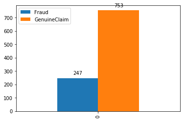

```python
count_fraud_reported =fraud_claims_dataframe[fraud_claims_dataframe.fraud_reported=="Y"].count()["age"]

count_genuineclaim_reported =fraud_claims_dataframe[fraud_claims_dataframe.fraud_reported=="N"].count()["age"]
fraud_data = {'Fraud': [count_fraud_reported], 'GenuineClaim':[count_genuineclaim_reported]  }
print(fraud_data)
fraud_df = pd.DataFrame(data=fraud_data)
ax = fraud_df.plot(kind="bar")
for p in ax.patches:
    ax.annotate(np.round(p.get_height(),decimals=2), (p.get_x()+p.get_width()/2., p.get_height()), ha='center', va='center', xytext=(0, 10), textcoords='offset points')
```

## Analyse the dataset

### Remove the columns which have lot of non distinct values (removal should be done based on understanding of the domain and should not be removed just because the values are all unique)

Eg : Policy number could be removed since it is a identifier which is primarily used to identify a claim and does not play any vitial role in predictive analysis. At the same time , data like age could be grouped in to different bins and analysis could be done even though age feature will have lot of distinct values.

```python
colsToDelete = ["policy_number", "policy_bind_date", "insured_zip", "incident_location", "incident_date"]
fraud_claims_dataframe = fraud_claims_dataframe.drop(columns=colsToDelete)
display(fraud_claims_dataframe)
display(fraud_claims_dataframe.dtypes)
```

|  | months_as_customer | age | policy_state | policy_csl | policy_deductable | policy_annual_premium | umbrella_limit | insured_sex | insured_education_level | insured_occupation | ... | witnesses | police_report_available | total_claim_amount | injury_claim | property_claim | vehicle_claim | auto_make | auto_model | auto_year | fraud_reported |
| --- | --- | --- | --- | --- | --- | --- | --- | --- | --- | --- | --- | --- | --- | --- | --- | --- | --- | --- | --- | --- | --- |
| 0 | 328 | 48 | OH | 250/500 | 1000 | 1406.91 | 0 | MALE | MD | craft-repair | ... | 2 | YES | 71610 | 6510 | 13020 | 52080 | Saab | 92x | 2004 | Y |
| 1 | 228 | 42 | IN | 250/500 | 2000 | 1197.22 | 5000000 | MALE | MD | machine-op-inspct | ... | 0 | ? | 5070 | 780 | 780 | 3510 | Mercedes | E400 | 2007 | Y |
| 2 | 134 | 29 | OH | 100/300 | 2000 | 1413.14 | 5000000 | FEMALE | PhD | sales | ... | 3 | NO | 34650 | 7700 | 3850 | 23100 | Dodge | RAM | 2007 | N |
| 3 | 256 | 41 | IL | 250/500 | 2000 | 1415.74 | 6000000 | FEMALE | PhD | armed-forces | ... | 2 | NO | 63400 | 6340 | 6340 | 50720 | Chevrolet | Tahoe | 2014 | Y |
| 4 | 228 | 44 | IL | 500/1000 | 1000 | 1583.91 | 6000000 | MALE | Associate | sales | ... | 1 | NO | 6500 | 1300 | 650 | 4550 | Accura | RSX | 2009 | N |
| 5 | 256 | 39 | OH | 250/500 | 1000 | 1351.10 | 0 | FEMALE | PhD | tech-support | ... | 2 | NO | 64100 | 6410 | 6410 | 51280 | Saab | 95 | 2003 | Y |
| 6 | 137 | 34 | IN | 250/500 | 1000 | 1333.35 | 0 | MALE | PhD | prof-specialty | ... | 0 | ? | 78650 | 21450 | 7150 | 50050 | Nissan | Pathfinder | 2012 | N |
| 7 | 165 | 37 | IL | 100/300 | 1000 | 1137.03 | 0 | MALE | Associate | tech-support | ... | 2 | YES | 51590 | 9380 | 9380 | 32830 | Audi | A5 | 2015 | N |
| 8 | 27 | 33 | IL | 100/300 | 500 | 1442.99 | 0 | FEMALE | PhD | other-service | ... | 1 | YES | 27700 | 2770 | 2770 | 22160 | Toyota | Camry | 2012 | N |
| 9 | 212 | 42 | IL | 100/300 | 500 | 1315.68 | 0 | MALE | PhD | priv-house-serv | ... | 1 | ? | 42300 | 4700 | 4700 | 32900 | Saab | 92x | 1996 | N |
| 10 | 235 | 42 | OH | 100/300 | 500 | 1253.12 | 4000000 | FEMALE | Masters | exec-managerial | ... | 2 | ? | 87010 | 7910 | 15820 | 63280 | Ford | F150 | 2002 | N |
| 11 | 447 | 61 | OH | 100/300 | 2000 | 1137.16 | 0 | FEMALE | High School | exec-managerial | ... | 2 | YES | 114920 | 17680 | 17680 | 79560 | Audi | A3 | 2006 | N |
| 12 | 60 | 23 | OH | 500/1000 | 500 | 1215.36 | 3000000 | MALE | MD | protective-serv | ... | 0 | NO | 56520 | 4710 | 9420 | 42390 | Saab | 95 | 2000 | N |
| 13 | 121 | 34 | OH | 100/300 | 1000 | 936.61 | 0 | FEMALE | MD | armed-forces | ... | 1 | NO | 7280 | 1120 | 1120 | 5040 | Toyota | Highlander | 2010 | N |
| 14 | 180 | 38 | OH | 250/500 | 2000 | 1301.13 | 0 | FEMALE | College | machine-op-inspct | ... | 2 | YES | 46200 | 4200 | 8400 | 33600 | Dodge | Neon | 2003 | Y |
| 15 | 473 | 58 | IN | 100/300 | 2000 | 1131.40 | 0 | FEMALE | MD | transport-moving | ... | 0 | NO | 63120 | 10520 | 10520 | 42080 | Accura | MDX | 1999 | Y |
| 16 | 70 | 26 | OH | 500/1000 | 1000 | 1199.44 | 5000000 | MALE | College | machine-op-inspct | ... | 2 | YES | 52110 | 5790 | 5790 | 40530 | Nissan | Maxima | 2012 | N |
| 17 | 140 | 31 | IN | 500/1000 | 500 | 708.64 | 6000000 | MALE | High School | machine-op-inspct | ... | 2 | YES | 77880 | 14160 | 7080 | 56640 | Suburu | Legacy | 2015 | N |
| 18 | 160 | 37 | OH | 500/1000 | 500 | 1374.22 | 0 | FEMALE | MD | craft-repair | ... | 0 | NO | 72930 | 6630 | 13260 | 53040 | Accura | TL | 2015 | N |
| 19 | 196 | 39 | IN | 500/1000 | 2000 | 1475.73 | 0 | FEMALE | High School | handlers-cleaners | ... | 0 | NO | 60400 | 6040 | 6040 | 48320 | Nissan | Pathfinder | 2014 | N |
| 20 | 460 | 62 | IN | 250/500 | 1000 | 1187.96 | 4000000 | MALE | JD | other-service | ... | 0 | ? | 47160 | 0 | 5240 | 41920 | Suburu | Impreza | 2011 | N |
| 21 | 217 | 41 | IL | 500/1000 | 2000 | 875.15 | 0 | FEMALE | Associate | machine-op-inspct | ... | 2 | ? | 37840 | 0 | 4730 | 33110 | Accura | RSX | 1996 | N |
| 22 | 370 | 55 | IL | 100/300 | 2000 | 972.18 | 0 | MALE | High School | prof-specialty | ... | 0 | YES | 71520 | 17880 | 5960 | 47680 | Suburu | Forrestor | 2000 | Y |
| 23 | 413 | 55 | IN | 100/300 | 2000 | 1268.79 | 0 | MALE | MD | priv-house-serv | ... | 2 | ? | 98160 | 8180 | 16360 | 73620 | Dodge | RAM | 2011 | Y |
| 24 | 237 | 40 | IN | 100/300 | 1000 | 883.31 | 0 | MALE | College | craft-repair | ... | 3 | NO | 77880 | 7080 | 14160 | 56640 | Ford | Escape | 2005 | N |
| 25 | 8 | 35 | OH | 100/300 | 2000 | 1266.92 | 0 | MALE | Masters | sales | ... | 3 | YES | 71500 | 16500 | 11000 | 44000 | Ford | Escape | 2006 | Y |
| 26 | 257 | 43 | IN | 100/300 | 2000 | 1322.10 | 0 | MALE | High School | prof-specialty | ... | 3 | YES | 9020 | 1640 | 820 | 6560 | Toyota | Camry | 2005 | N |
| 27 | 202 | 34 | IN | 100/300 | 500 | 848.07 | 3000000 | MALE | JD | exec-managerial | ... | 1 | ? | 5720 | 1040 | 520 | 4160 | Suburu | Forrestor | 2003 | Y |
| 28 | 224 | 40 | OH | 100/300 | 2000 | 1291.70 | 0 | FEMALE | JD | sales | ... | 0 | YES | 69840 | 7760 | 15520 | 46560 | Dodge | Neon | 2009 | N |
| 29 | 241 | 45 | IL | 500/1000 | 2000 | 1104.50 | 0 | FEMALE | PhD | machine-op-inspct | ... | 2 | NO | 91650 | 14100 | 14100 | 63450 | Accura | TL | 2011 | N |
| ... | ... | ... | ... | ... | ... | ... | ... | ... | ... | ... | ... | ... | ... | ... | ... | ... | ... | ... | ... | ... | ... |
| 970 | 213 | 35 | OH | 250/500 | 500 | 871.46 | 0 | MALE | MD | tech-support | ... | 0 | YES | 74140 | 13480 | 6740 | 53920 | Ford | Escape | 2007 | N |
| 971 | 79 | 25 | OH | 500/1000 | 500 | 1863.04 | 0 | FEMALE | Associate | priv-house-serv | ... | 1 | ? | 67800 | 13560 | 6780 | 47460 | Mercedes | C300 | 1995 | N |
| 972 | 232 | 44 | OH | 250/500 | 2000 | 1181.64 | 0 | MALE | College | other-service | ... | 1 | YES | 55400 | 5540 | 11080 | 38780 | Jeep | Grand Cherokee | 2002 | Y |
| 973 | 230 | 37 | IL | 500/1000 | 1000 | 1060.74 | 0 | MALE | PhD | tech-support | ... | 3 | ? | 49100 | 9820 | 4910 | 34370 | Suburu | Impreza | 1996 | Y |
| 974 | 234 | 41 | IN | 100/300 | 500 | 951.56 | 0 | FEMALE | JD | transport-moving | ... | 1 | ? | 98280 | 15120 | 7560 | 75600 | Chevrolet | Tahoe | 2007 | Y |
| 975 | 240 | 40 | IN | 100/300 | 500 | 1533.71 | 9000000 | FEMALE | JD | protective-serv | ... | 2 | ? | 66550 | 6050 | 12100 | 48400 | Ford | Escape | 2008 | N |
| 976 | 143 | 33 | OH | 500/1000 | 1000 | 1200.09 | 0 | FEMALE | Associate | craft-repair | ... | 2 | ? | 70400 | 14080 | 7040 | 49280 | Accura | RSX | 2002 | N |
| 977 | 266 | 42 | IN | 100/300 | 500 | 1093.83 | 4000000 | MALE | Associate | adm-clerical | ... | 1 | NO | 53280 | 4440 | 8880 | 39960 | Suburu | Impreza | 2015 | Y |
| 978 | 89 | 32 | IN | 250/500 | 1000 | 988.93 | 0 | FEMALE | High School | craft-repair | ... | 3 | YES | 84590 | 15380 | 15380 | 53830 | Dodge | Neon | 1999 | N |
| 979 | 229 | 37 | IN | 500/1000 | 1000 | 1331.94 | 0 | FEMALE | Masters | farming-fishing | ... | 2 | YES | 54560 | 9920 | 9920 | 34720 | Saab | 95 | 2004 | N |
| 980 | 245 | 40 | IL | 500/1000 | 1000 | 1361.45 | 0 | MALE | PhD | handlers-cleaners | ... | 2 | YES | 82170 | 7470 | 7470 | 67230 | Suburu | Forrestor | 1999 | N |
| 981 | 50 | 44 | OH | 250/500 | 2000 | 1188.51 | 0 | MALE | College | handlers-cleaners | ... | 2 | NO | 61100 | 6110 | 12220 | 42770 | Dodge | Neon | 2008 | N |
| 982 | 230 | 43 | IN | 500/1000 | 2000 | 1101.83 | 0 | MALE | High School | exec-managerial | ... | 3 | YES | 51900 | 5190 | 10380 | 36330 | BMW | M5 | 2011 | Y |
| 983 | 17 | 39 | IL | 250/500 | 1000 | 840.95 | 0 | FEMALE | JD | adm-clerical | ... | 1 | ? | 3440 | 430 | 430 | 2580 | Suburu | Legacy | 2002 | N |
| 984 | 163 | 36 | IN | 250/500 | 1000 | 1503.21 | 0 | MALE | MD | other-service | ... | 1 | NO | 51390 | 5710 | 11420 | 34260 | Toyota | Corolla | 2013 | N |
| 985 | 29 | 32 | OH | 100/300 | 1000 | 1722.50 | 0 | MALE | High School | other-service | ... | 2 | ? | 76900 | 7690 | 7690 | 61520 | Jeep | Wrangler | 1995 | N |
| 986 | 232 | 42 | IN | 100/300 | 500 | 944.03 | 0 | MALE | College | handlers-cleaners | ... | 3 | ? | 77000 | 15400 | 7700 | 53900 | Toyota | Highlander | 2015 | Y |
| 987 | 235 | 39 | IL | 500/1000 | 2000 | 1453.61 | 4000000 | MALE | JD | craft-repair | ... | 3 | ? | 60320 | 9280 | 9280 | 41760 | Chevrolet | Tahoe | 2012 | Y |
| 988 | 295 | 46 | IN | 100/300 | 500 | 1672.88 | 0 | FEMALE | High School | armed-forces | ... | 1 | NO | 60700 | 12140 | 6070 | 42490 | Honda | Civic | 1997 | N |
| 989 | 22 | 21 | IN | 250/500 | 1000 | 1248.05 | 0 | FEMALE | High School | exec-managerial | ... | 2 | ? | 53280 | 5920 | 0 | 47360 | Chevrolet | Malibu | 2015 | N |
| 990 | 286 | 43 | IL | 100/300 | 500 | 1564.43 | 3000000 | FEMALE | MD | prof-specialty | ... | 2 | YES | 34290 | 3810 | 3810 | 26670 | Jeep | Grand Cherokee | 2013 | N |
| 991 | 257 | 44 | OH | 100/300 | 1000 | 1280.88 | 0 | MALE | MD | other-service | ... | 1 | NO | 46980 | 0 | 5220 | 41760 | Accura | TL | 2002 | N |
| 992 | 94 | 26 | IN | 100/300 | 500 | 722.66 | 0 | MALE | MD | exec-managerial | ... | 2 | YES | 36700 | 3670 | 7340 | 25690 | Nissan | Pathfinder | 2010 | N |
| 993 | 124 | 28 | OH | 250/500 | 1000 | 1235.14 | 0 | MALE | MD | exec-managerial | ... | 1 | ? | 60200 | 6020 | 6020 | 48160 | Volkswagen | Passat | 2012 | N |
| 994 | 141 | 30 | IN | 500/1000 | 1000 | 1347.04 | 0 | MALE | High School | sales | ... | 2 | YES | 6480 | 540 | 1080 | 4860 | Honda | Civic | 1996 | N |
| 995 | 3 | 38 | OH | 500/1000 | 1000 | 1310.80 | 0 | FEMALE | Masters | craft-repair | ... | 1 | ? | 87200 | 17440 | 8720 | 61040 | Honda | Accord | 2006 | N |
| 996 | 285 | 41 | IL | 100/300 | 1000 | 1436.79 | 0 | FEMALE | PhD | prof-specialty | ... | 3 | ? | 108480 | 18080 | 18080 | 72320 | Volkswagen | Passat | 2015 | N |
| 997 | 130 | 34 | OH | 250/500 | 500 | 1383.49 | 3000000 | FEMALE | Masters | armed-forces | ... | 3 | YES | 67500 | 7500 | 7500 | 52500 | Suburu | Impreza | 1996 | N |
| 998 | 458 | 62 | IL | 500/1000 | 2000 | 1356.92 | 5000000 | MALE | Associate | handlers-cleaners | ... | 1 | YES | 46980 | 5220 | 5220 | 36540 | Audi | A5 | 1998 | N |
| 999 | 456 | 60 | OH | 250/500 | 1000 | 766.19 | 0 | FEMALE | Associate | sales | ... | 3 | ? | 5060 | 460 | 920 | 3680 | Mercedes | E400 | 2007 | N |

1000 rows × 34 columns

```
months_as_customer               int64
age                              int64
policy_state                    object
policy_csl                      object
policy_deductable                int64
policy_annual_premium          float64
umbrella_limit                   int64
insured_sex                     object
insured_education_level         object
insured_occupation              object
insured_hobbies                 object
insured_relationship            object
capital-gains                    int64
capital-loss                     int64
incident_type                   object
collision_type                  object
incident_severity               object
authorities_contacted           object
incident_state                  object
incident_city                   object
incident_hour_of_the_day         int64
number_of_vehicles_involved      int64
property_damage                 object
bodily_injuries                  int64
witnesses                        int64
police_report_available         object
total_claim_amount               int64
injury_claim                     int64
property_claim                   int64
vehicle_claim                    int64
auto_make                       object
auto_model                      object
auto_year                        int64
fraud_reported                  object
dtype: object
```

## Analyse the dataset

### Identify the categorical columns

Identify the categorical columns so that they could be made numeric and could be used for transformation etc. Also lot of algorithms perform which use distance would like to have numeric values in feature set.

```python
stringColList = fraud_claims_dataframe.select_dtypes(include=["object"]).columns
print(stringColList)
```

```
Index(['policy_state', 'policy_csl', 'insured_sex', 'insured_education_level',
       'insured_occupation', 'insured_hobbies', 'insured_relationship',
       'incident_type', 'collision_type', 'incident_severity',
       'authorities_contacted', 'incident_state', 'incident_city',
       'property_damage', 'police_report_available', 'auto_make', 'auto_model',
       'fraud_reported'],
      dtype='object')
```

## Analyse the dataset

### Convert the categorical columns to numerical types using panda's factorise method.

```python
fraud_claims_dataframe[stringColList] = fraud_claims_dataframe[stringColList].apply(lambda x: x.factorize()[0])
display(fraud_claims_dataframe)
```

|  | months_as_customer | age | policy_state | policy_csl | policy_deductable | policy_annual_premium | umbrella_limit | insured_sex | insured_education_level | insured_occupation | ... | witnesses | police_report_available | total_claim_amount | injury_claim | property_claim | vehicle_claim | auto_make | auto_model | auto_year | fraud_reported |
| --- | --- | --- | --- | --- | --- | --- | --- | --- | --- | --- | --- | --- | --- | --- | --- | --- | --- | --- | --- | --- | --- |
| 0 | 328 | 48 | 0 | 0 | 1000 | 1406.91 | 0 | 0 | 0 | 0 | ... | 2 | 0 | 71610 | 6510 | 13020 | 52080 | 0 | 0 | 2004 | 0 |
| 1 | 228 | 42 | 1 | 0 | 2000 | 1197.22 | 5000000 | 0 | 0 | 1 | ... | 0 | 1 | 5070 | 780 | 780 | 3510 | 1 | 1 | 2007 | 0 |
| 2 | 134 | 29 | 0 | 1 | 2000 | 1413.14 | 5000000 | 1 | 1 | 2 | ... | 3 | 2 | 34650 | 7700 | 3850 | 23100 | 2 | 2 | 2007 | 1 |
| 3 | 256 | 41 | 2 | 0 | 2000 | 1415.74 | 6000000 | 1 | 1 | 3 | ... | 2 | 2 | 63400 | 6340 | 6340 | 50720 | 3 | 3 | 2014 | 0 |
| 4 | 228 | 44 | 2 | 2 | 1000 | 1583.91 | 6000000 | 0 | 2 | 2 | ... | 1 | 2 | 6500 | 1300 | 650 | 4550 | 4 | 4 | 2009 | 1 |
| 5 | 256 | 39 | 0 | 0 | 1000 | 1351.10 | 0 | 1 | 1 | 4 | ... | 2 | 2 | 64100 | 6410 | 6410 | 51280 | 0 | 5 | 2003 | 0 |
| 6 | 137 | 34 | 1 | 0 | 1000 | 1333.35 | 0 | 0 | 1 | 5 | ... | 0 | 1 | 78650 | 21450 | 7150 | 50050 | 5 | 6 | 2012 | 1 |
| 7 | 165 | 37 | 2 | 1 | 1000 | 1137.03 | 0 | 0 | 2 | 4 | ... | 2 | 0 | 51590 | 9380 | 9380 | 32830 | 6 | 7 | 2015 | 1 |
| 8 | 27 | 33 | 2 | 1 | 500 | 1442.99 | 0 | 1 | 1 | 6 | ... | 1 | 0 | 27700 | 2770 | 2770 | 22160 | 7 | 8 | 2012 | 1 |
| 9 | 212 | 42 | 2 | 1 | 500 | 1315.68 | 0 | 0 | 1 | 7 | ... | 1 | 1 | 42300 | 4700 | 4700 | 32900 | 0 | 0 | 1996 | 1 |
| 10 | 235 | 42 | 0 | 1 | 500 | 1253.12 | 4000000 | 1 | 3 | 8 | ... | 2 | 1 | 87010 | 7910 | 15820 | 63280 | 8 | 9 | 2002 | 1 |
| 11 | 447 | 61 | 0 | 1 | 2000 | 1137.16 | 0 | 1 | 4 | 8 | ... | 2 | 0 | 114920 | 17680 | 17680 | 79560 | 6 | 10 | 2006 | 1 |
| 12 | 60 | 23 | 0 | 2 | 500 | 1215.36 | 3000000 | 0 | 0 | 9 | ... | 0 | 2 | 56520 | 4710 | 9420 | 42390 | 0 | 5 | 2000 | 1 |
| 13 | 121 | 34 | 0 | 1 | 1000 | 936.61 | 0 | 1 | 0 | 3 | ... | 1 | 2 | 7280 | 1120 | 1120 | 5040 | 7 | 11 | 2010 | 1 |
| 14 | 180 | 38 | 0 | 0 | 2000 | 1301.13 | 0 | 1 | 5 | 1 | ... | 2 | 0 | 46200 | 4200 | 8400 | 33600 | 2 | 12 | 2003 | 0 |
| 15 | 473 | 58 | 1 | 1 | 2000 | 1131.40 | 0 | 1 | 0 | 10 | ... | 0 | 2 | 63120 | 10520 | 10520 | 42080 | 4 | 13 | 1999 | 0 |
| 16 | 70 | 26 | 0 | 2 | 1000 | 1199.44 | 5000000 | 0 | 5 | 1 | ... | 2 | 0 | 52110 | 5790 | 5790 | 40530 | 5 | 14 | 2012 | 1 |
| 17 | 140 | 31 | 1 | 2 | 500 | 708.64 | 6000000 | 0 | 4 | 1 | ... | 2 | 0 | 77880 | 14160 | 7080 | 56640 | 9 | 15 | 2015 | 1 |
| 18 | 160 | 37 | 0 | 2 | 500 | 1374.22 | 0 | 1 | 0 | 0 | ... | 0 | 2 | 72930 | 6630 | 13260 | 53040 | 4 | 16 | 2015 | 1 |
| 19 | 196 | 39 | 1 | 2 | 2000 | 1475.73 | 0 | 1 | 4 | 11 | ... | 0 | 2 | 60400 | 6040 | 6040 | 48320 | 5 | 6 | 2014 | 1 |
| 20 | 460 | 62 | 1 | 0 | 1000 | 1187.96 | 4000000 | 0 | 6 | 6 | ... | 0 | 1 | 47160 | 0 | 5240 | 41920 | 9 | 17 | 2011 | 1 |
| 21 | 217 | 41 | 2 | 2 | 2000 | 875.15 | 0 | 1 | 2 | 1 | ... | 2 | 1 | 37840 | 0 | 4730 | 33110 | 4 | 4 | 1996 | 1 |
| 22 | 370 | 55 | 2 | 1 | 2000 | 972.18 | 0 | 0 | 4 | 5 | ... | 0 | 0 | 71520 | 17880 | 5960 | 47680 | 9 | 18 | 2000 | 0 |
| 23 | 413 | 55 | 1 | 1 | 2000 | 1268.79 | 0 | 0 | 0 | 7 | ... | 2 | 1 | 98160 | 8180 | 16360 | 73620 | 2 | 2 | 2011 | 0 |
| 24 | 237 | 40 | 1 | 1 | 1000 | 883.31 | 0 | 0 | 5 | 0 | ... | 3 | 2 | 77880 | 7080 | 14160 | 56640 | 8 | 19 | 2005 | 1 |
| 25 | 8 | 35 | 0 | 1 | 2000 | 1266.92 | 0 | 0 | 3 | 2 | ... | 3 | 0 | 71500 | 16500 | 11000 | 44000 | 8 | 19 | 2006 | 0 |
| 26 | 257 | 43 | 1 | 1 | 2000 | 1322.10 | 0 | 0 | 4 | 5 | ... | 3 | 0 | 9020 | 1640 | 820 | 6560 | 7 | 8 | 2005 | 1 |
| 27 | 202 | 34 | 1 | 1 | 500 | 848.07 | 3000000 | 0 | 6 | 8 | ... | 1 | 1 | 5720 | 1040 | 520 | 4160 | 9 | 18 | 2003 | 0 |
| 28 | 224 | 40 | 0 | 1 | 2000 | 1291.70 | 0 | 1 | 6 | 2 | ... | 0 | 0 | 69840 | 7760 | 15520 | 46560 | 2 | 12 | 2009 | 1 |
| 29 | 241 | 45 | 2 | 2 | 2000 | 1104.50 | 0 | 1 | 1 | 1 | ... | 2 | 2 | 91650 | 14100 | 14100 | 63450 | 4 | 16 | 2011 | 1 |
| ... | ... | ... | ... | ... | ... | ... | ... | ... | ... | ... | ... | ... | ... | ... | ... | ... | ... | ... | ... | ... | ... |
| 970 | 213 | 35 | 0 | 0 | 500 | 871.46 | 0 | 0 | 0 | 4 | ... | 0 | 0 | 74140 | 13480 | 6740 | 53920 | 8 | 19 | 2007 | 1 |
| 971 | 79 | 25 | 0 | 2 | 500 | 1863.04 | 0 | 1 | 2 | 7 | ... | 1 | 1 | 67800 | 13560 | 6780 | 47460 | 1 | 22 | 1995 | 1 |
| 972 | 232 | 44 | 0 | 0 | 2000 | 1181.64 | 0 | 0 | 5 | 6 | ... | 1 | 0 | 55400 | 5540 | 11080 | 38780 | 11 | 38 | 2002 | 0 |
| 973 | 230 | 37 | 2 | 2 | 1000 | 1060.74 | 0 | 0 | 1 | 4 | ... | 3 | 1 | 49100 | 9820 | 4910 | 34370 | 9 | 17 | 1996 | 0 |
| 974 | 234 | 41 | 1 | 1 | 500 | 951.56 | 0 | 1 | 6 | 10 | ... | 1 | 1 | 98280 | 15120 | 7560 | 75600 | 3 | 3 | 2007 | 0 |
| 975 | 240 | 40 | 1 | 1 | 500 | 1533.71 | 9000000 | 1 | 6 | 9 | ... | 2 | 1 | 66550 | 6050 | 12100 | 48400 | 8 | 19 | 2008 | 1 |
| 976 | 143 | 33 | 0 | 2 | 1000 | 1200.09 | 0 | 1 | 2 | 0 | ... | 2 | 1 | 70400 | 14080 | 7040 | 49280 | 4 | 4 | 2002 | 1 |
| 977 | 266 | 42 | 1 | 1 | 500 | 1093.83 | 4000000 | 0 | 2 | 12 | ... | 1 | 2 | 53280 | 4440 | 8880 | 39960 | 9 | 17 | 2015 | 0 |
| 978 | 89 | 32 | 1 | 0 | 1000 | 988.93 | 0 | 1 | 4 | 0 | ... | 3 | 0 | 84590 | 15380 | 15380 | 53830 | 2 | 12 | 1999 | 1 |
| 979 | 229 | 37 | 1 | 2 | 1000 | 1331.94 | 0 | 1 | 3 | 13 | ... | 2 | 0 | 54560 | 9920 | 9920 | 34720 | 0 | 5 | 2004 | 1 |
| 980 | 245 | 40 | 2 | 2 | 1000 | 1361.45 | 0 | 0 | 1 | 11 | ... | 2 | 0 | 82170 | 7470 | 7470 | 67230 | 9 | 18 | 1999 | 1 |
| 981 | 50 | 44 | 0 | 0 | 2000 | 1188.51 | 0 | 0 | 5 | 11 | ... | 2 | 2 | 61100 | 6110 | 12220 | 42770 | 2 | 12 | 2008 | 1 |
| 982 | 230 | 43 | 1 | 2 | 2000 | 1101.83 | 0 | 0 | 4 | 8 | ... | 3 | 0 | 51900 | 5190 | 10380 | 36330 | 10 | 24 | 2011 | 0 |
| 983 | 17 | 39 | 2 | 0 | 1000 | 840.95 | 0 | 1 | 6 | 12 | ... | 1 | 1 | 3440 | 430 | 430 | 2580 | 9 | 15 | 2002 | 1 |
| 984 | 163 | 36 | 1 | 0 | 1000 | 1503.21 | 0 | 0 | 0 | 6 | ... | 1 | 2 | 51390 | 5710 | 11420 | 34260 | 7 | 20 | 2013 | 1 |
| 985 | 29 | 32 | 0 | 1 | 1000 | 1722.50 | 0 | 0 | 4 | 6 | ... | 2 | 1 | 76900 | 7690 | 7690 | 61520 | 11 | 23 | 1995 | 1 |
| 986 | 232 | 42 | 1 | 1 | 500 | 944.03 | 0 | 0 | 5 | 11 | ... | 3 | 1 | 77000 | 15400 | 7700 | 53900 | 7 | 11 | 2015 | 0 |
| 987 | 235 | 39 | 2 | 2 | 2000 | 1453.61 | 4000000 | 0 | 6 | 0 | ... | 3 | 1 | 60320 | 9280 | 9280 | 41760 | 3 | 3 | 2012 | 0 |
| 988 | 295 | 46 | 1 | 1 | 500 | 1672.88 | 0 | 1 | 4 | 3 | ... | 1 | 2 | 60700 | 12140 | 6070 | 42490 | 12 | 26 | 1997 | 1 |
| 989 | 22 | 21 | 1 | 0 | 1000 | 1248.05 | 0 | 1 | 4 | 8 | ... | 2 | 1 | 53280 | 5920 | 0 | 47360 | 3 | 33 | 2015 | 1 |
| 990 | 286 | 43 | 2 | 1 | 500 | 1564.43 | 3000000 | 1 | 0 | 5 | ... | 2 | 0 | 34290 | 3810 | 3810 | 26670 | 11 | 38 | 2013 | 1 |
| 991 | 257 | 44 | 0 | 1 | 1000 | 1280.88 | 0 | 0 | 0 | 6 | ... | 1 | 2 | 46980 | 0 | 5220 | 41760 | 4 | 16 | 2002 | 1 |
| 992 | 94 | 26 | 1 | 1 | 500 | 722.66 | 0 | 0 | 0 | 8 | ... | 2 | 0 | 36700 | 3670 | 7340 | 25690 | 5 | 6 | 2010 | 1 |
| 993 | 124 | 28 | 0 | 0 | 1000 | 1235.14 | 0 | 0 | 0 | 8 | ... | 1 | 1 | 60200 | 6020 | 6020 | 48160 | 13 | 27 | 2012 | 1 |
| 994 | 141 | 30 | 1 | 2 | 1000 | 1347.04 | 0 | 0 | 4 | 2 | ... | 2 | 0 | 6480 | 540 | 1080 | 4860 | 12 | 26 | 1996 | 1 |
| 995 | 3 | 38 | 0 | 2 | 1000 | 1310.80 | 0 | 1 | 3 | 0 | ... | 1 | 1 | 87200 | 17440 | 8720 | 61040 | 12 | 31 | 2006 | 1 |
| 996 | 285 | 41 | 2 | 1 | 1000 | 1436.79 | 0 | 1 | 1 | 5 | ... | 3 | 1 | 108480 | 18080 | 18080 | 72320 | 13 | 27 | 2015 | 1 |
| 997 | 130 | 34 | 0 | 0 | 500 | 1383.49 | 3000000 | 1 | 3 | 3 | ... | 3 | 0 | 67500 | 7500 | 7500 | 52500 | 9 | 17 | 1996 | 1 |
| 998 | 458 | 62 | 2 | 2 | 2000 | 1356.92 | 5000000 | 0 | 2 | 11 | ... | 1 | 0 | 46980 | 5220 | 5220 | 36540 | 6 | 7 | 1998 | 1 |
| 999 | 456 | 60 | 0 | 0 | 1000 | 766.19 | 0 | 1 | 2 | 2 | ... | 3 | 1 | 5060 | 460 | 920 | 3680 | 1 | 1 | 2007 | 1 |

1000 rows × 34 columns

## Analyse the dataset

### Convert few of the columns like age, Months as customer in to different bins so that they are more meaningful

```python
# Converting range of age to different bins
bins = [0,18,30,40,50,60,70]
labels=[0,1,2,3,4,5]
fraud_claims_dataframe['age'] = pd.cut(fraud_claims_dataframe['age'], bins=bins, labels=labels, include_lowest=True)
#print (fraud_claims_dataframe)
#converting months as customer to different bins
bins=[0,60,120,180,240,300,360,420,480,540,600,1500]
labels=[0,1,2,3,4,5,6,7,8,9,10]
fraud_claims_dataframe['months_as_customer'] = pd.cut(fraud_claims_dataframe['months_as_customer'], bins=bins, labels=labels, include_lowest=True)
display (fraud_claims_dataframe)
```

|  | months_as_customer | age | policy_state | policy_csl | policy_deductable | policy_annual_premium | umbrella_limit | insured_sex | insured_education_level | insured_occupation | ... | witnesses | police_report_available | total_claim_amount | injury_claim | property_claim | vehicle_claim | auto_make | auto_model | auto_year | fraud_reported |
| --- | --- | --- | --- | --- | --- | --- | --- | --- | --- | --- | --- | --- | --- | --- | --- | --- | --- | --- | --- | --- | --- |
| 0 | 5 | 3 | 0 | 0 | 1000 | 1406.91 | 0 | 0 | 0 | 0 | ... | 2 | 0 | 71610 | 6510 | 13020 | 52080 | 0 | 0 | 2004 | 0 |
| 1 | 3 | 3 | 1 | 0 | 2000 | 1197.22 | 5000000 | 0 | 0 | 1 | ... | 0 | 1 | 5070 | 780 | 780 | 3510 | 1 | 1 | 2007 | 0 |
| 2 | 2 | 1 | 0 | 1 | 2000 | 1413.14 | 5000000 | 1 | 1 | 2 | ... | 3 | 2 | 34650 | 7700 | 3850 | 23100 | 2 | 2 | 2007 | 1 |
| 3 | 4 | 3 | 2 | 0 | 2000 | 1415.74 | 6000000 | 1 | 1 | 3 | ... | 2 | 2 | 63400 | 6340 | 6340 | 50720 | 3 | 3 | 2014 | 0 |
| 4 | 3 | 3 | 2 | 2 | 1000 | 1583.91 | 6000000 | 0 | 2 | 2 | ... | 1 | 2 | 6500 | 1300 | 650 | 4550 | 4 | 4 | 2009 | 1 |
| 5 | 4 | 2 | 0 | 0 | 1000 | 1351.10 | 0 | 1 | 1 | 4 | ... | 2 | 2 | 64100 | 6410 | 6410 | 51280 | 0 | 5 | 2003 | 0 |
| 6 | 2 | 2 | 1 | 0 | 1000 | 1333.35 | 0 | 0 | 1 | 5 | ... | 0 | 1 | 78650 | 21450 | 7150 | 50050 | 5 | 6 | 2012 | 1 |
| 7 | 2 | 2 | 2 | 1 | 1000 | 1137.03 | 0 | 0 | 2 | 4 | ... | 2 | 0 | 51590 | 9380 | 9380 | 32830 | 6 | 7 | 2015 | 1 |
| 8 | 0 | 2 | 2 | 1 | 500 | 1442.99 | 0 | 1 | 1 | 6 | ... | 1 | 0 | 27700 | 2770 | 2770 | 22160 | 7 | 8 | 2012 | 1 |
| 9 | 3 | 3 | 2 | 1 | 500 | 1315.68 | 0 | 0 | 1 | 7 | ... | 1 | 1 | 42300 | 4700 | 4700 | 32900 | 0 | 0 | 1996 | 1 |
| 10 | 3 | 3 | 0 | 1 | 500 | 1253.12 | 4000000 | 1 | 3 | 8 | ... | 2 | 1 | 87010 | 7910 | 15820 | 63280 | 8 | 9 | 2002 | 1 |
| 11 | 7 | 5 | 0 | 1 | 2000 | 1137.16 | 0 | 1 | 4 | 8 | ... | 2 | 0 | 114920 | 17680 | 17680 | 79560 | 6 | 10 | 2006 | 1 |
| 12 | 0 | 1 | 0 | 2 | 500 | 1215.36 | 3000000 | 0 | 0 | 9 | ... | 0 | 2 | 56520 | 4710 | 9420 | 42390 | 0 | 5 | 2000 | 1 |
| 13 | 2 | 2 | 0 | 1 | 1000 | 936.61 | 0 | 1 | 0 | 3 | ... | 1 | 2 | 7280 | 1120 | 1120 | 5040 | 7 | 11 | 2010 | 1 |
| 14 | 2 | 2 | 0 | 0 | 2000 | 1301.13 | 0 | 1 | 5 | 1 | ... | 2 | 0 | 46200 | 4200 | 8400 | 33600 | 2 | 12 | 2003 | 0 |
| 15 | 7 | 4 | 1 | 1 | 2000 | 1131.40 | 0 | 1 | 0 | 10 | ... | 0 | 2 | 63120 | 10520 | 10520 | 42080 | 4 | 13 | 1999 | 0 |
| 16 | 1 | 1 | 0 | 2 | 1000 | 1199.44 | 5000000 | 0 | 5 | 1 | ... | 2 | 0 | 52110 | 5790 | 5790 | 40530 | 5 | 14 | 2012 | 1 |
| 17 | 2 | 2 | 1 | 2 | 500 | 708.64 | 6000000 | 0 | 4 | 1 | ... | 2 | 0 | 77880 | 14160 | 7080 | 56640 | 9 | 15 | 2015 | 1 |
| 18 | 2 | 2 | 0 | 2 | 500 | 1374.22 | 0 | 1 | 0 | 0 | ... | 0 | 2 | 72930 | 6630 | 13260 | 53040 | 4 | 16 | 2015 | 1 |
| 19 | 3 | 2 | 1 | 2 | 2000 | 1475.73 | 0 | 1 | 4 | 11 | ... | 0 | 2 | 60400 | 6040 | 6040 | 48320 | 5 | 6 | 2014 | 1 |
| 20 | 7 | 5 | 1 | 0 | 1000 | 1187.96 | 4000000 | 0 | 6 | 6 | ... | 0 | 1 | 47160 | 0 | 5240 | 41920 | 9 | 17 | 2011 | 1 |
| 21 | 3 | 3 | 2 | 2 | 2000 | 875.15 | 0 | 1 | 2 | 1 | ... | 2 | 1 | 37840 | 0 | 4730 | 33110 | 4 | 4 | 1996 | 1 |
| 22 | 6 | 4 | 2 | 1 | 2000 | 972.18 | 0 | 0 | 4 | 5 | ... | 0 | 0 | 71520 | 17880 | 5960 | 47680 | 9 | 18 | 2000 | 0 |
| 23 | 6 | 4 | 1 | 1 | 2000 | 1268.79 | 0 | 0 | 0 | 7 | ... | 2 | 1 | 98160 | 8180 | 16360 | 73620 | 2 | 2 | 2011 | 0 |
| 24 | 3 | 2 | 1 | 1 | 1000 | 883.31 | 0 | 0 | 5 | 0 | ... | 3 | 2 | 77880 | 7080 | 14160 | 56640 | 8 | 19 | 2005 | 1 |
| 25 | 0 | 2 | 0 | 1 | 2000 | 1266.92 | 0 | 0 | 3 | 2 | ... | 3 | 0 | 71500 | 16500 | 11000 | 44000 | 8 | 19 | 2006 | 0 |
| 26 | 4 | 3 | 1 | 1 | 2000 | 1322.10 | 0 | 0 | 4 | 5 | ... | 3 | 0 | 9020 | 1640 | 820 | 6560 | 7 | 8 | 2005 | 1 |
| 27 | 3 | 2 | 1 | 1 | 500 | 848.07 | 3000000 | 0 | 6 | 8 | ... | 1 | 1 | 5720 | 1040 | 520 | 4160 | 9 | 18 | 2003 | 0 |
| 28 | 3 | 2 | 0 | 1 | 2000 | 1291.70 | 0 | 1 | 6 | 2 | ... | 0 | 0 | 69840 | 7760 | 15520 | 46560 | 2 | 12 | 2009 | 1 |
| 29 | 4 | 3 | 2 | 2 | 2000 | 1104.50 | 0 | 1 | 1 | 1 | ... | 2 | 2 | 91650 | 14100 | 14100 | 63450 | 4 | 16 | 2011 | 1 |
| ... | ... | ... | ... | ... | ... | ... | ... | ... | ... | ... | ... | ... | ... | ... | ... | ... | ... | ... | ... | ... | ... |
| 970 | 3 | 2 | 0 | 0 | 500 | 871.46 | 0 | 0 | 0 | 4 | ... | 0 | 0 | 74140 | 13480 | 6740 | 53920 | 8 | 19 | 2007 | 1 |
| 971 | 1 | 1 | 0 | 2 | 500 | 1863.04 | 0 | 1 | 2 | 7 | ... | 1 | 1 | 67800 | 13560 | 6780 | 47460 | 1 | 22 | 1995 | 1 |
| 972 | 3 | 3 | 0 | 0 | 2000 | 1181.64 | 0 | 0 | 5 | 6 | ... | 1 | 0 | 55400 | 5540 | 11080 | 38780 | 11 | 38 | 2002 | 0 |
| 973 | 3 | 2 | 2 | 2 | 1000 | 1060.74 | 0 | 0 | 1 | 4 | ... | 3 | 1 | 49100 | 9820 | 4910 | 34370 | 9 | 17 | 1996 | 0 |
| 974 | 3 | 3 | 1 | 1 | 500 | 951.56 | 0 | 1 | 6 | 10 | ... | 1 | 1 | 98280 | 15120 | 7560 | 75600 | 3 | 3 | 2007 | 0 |
| 975 | 3 | 2 | 1 | 1 | 500 | 1533.71 | 9000000 | 1 | 6 | 9 | ... | 2 | 1 | 66550 | 6050 | 12100 | 48400 | 8 | 19 | 2008 | 1 |
| 976 | 2 | 2 | 0 | 2 | 1000 | 1200.09 | 0 | 1 | 2 | 0 | ... | 2 | 1 | 70400 | 14080 | 7040 | 49280 | 4 | 4 | 2002 | 1 |
| 977 | 4 | 3 | 1 | 1 | 500 | 1093.83 | 4000000 | 0 | 2 | 12 | ... | 1 | 2 | 53280 | 4440 | 8880 | 39960 | 9 | 17 | 2015 | 0 |
| 978 | 1 | 2 | 1 | 0 | 1000 | 988.93 | 0 | 1 | 4 | 0 | ... | 3 | 0 | 84590 | 15380 | 15380 | 53830 | 2 | 12 | 1999 | 1 |
| 979 | 3 | 2 | 1 | 2 | 1000 | 1331.94 | 0 | 1 | 3 | 13 | ... | 2 | 0 | 54560 | 9920 | 9920 | 34720 | 0 | 5 | 2004 | 1 |
| 980 | 4 | 2 | 2 | 2 | 1000 | 1361.45 | 0 | 0 | 1 | 11 | ... | 2 | 0 | 82170 | 7470 | 7470 | 67230 | 9 | 18 | 1999 | 1 |
| 981 | 0 | 3 | 0 | 0 | 2000 | 1188.51 | 0 | 0 | 5 | 11 | ... | 2 | 2 | 61100 | 6110 | 12220 | 42770 | 2 | 12 | 2008 | 1 |
| 982 | 3 | 3 | 1 | 2 | 2000 | 1101.83 | 0 | 0 | 4 | 8 | ... | 3 | 0 | 51900 | 5190 | 10380 | 36330 | 10 | 24 | 2011 | 0 |
| 983 | 0 | 2 | 2 | 0 | 1000 | 840.95 | 0 | 1 | 6 | 12 | ... | 1 | 1 | 3440 | 430 | 430 | 2580 | 9 | 15 | 2002 | 1 |
| 984 | 2 | 2 | 1 | 0 | 1000 | 1503.21 | 0 | 0 | 0 | 6 | ... | 1 | 2 | 51390 | 5710 | 11420 | 34260 | 7 | 20 | 2013 | 1 |
| 985 | 0 | 2 | 0 | 1 | 1000 | 1722.50 | 0 | 0 | 4 | 6 | ... | 2 | 1 | 76900 | 7690 | 7690 | 61520 | 11 | 23 | 1995 | 1 |
| 986 | 3 | 3 | 1 | 1 | 500 | 944.03 | 0 | 0 | 5 | 11 | ... | 3 | 1 | 77000 | 15400 | 7700 | 53900 | 7 | 11 | 2015 | 0 |
| 987 | 3 | 2 | 2 | 2 | 2000 | 1453.61 | 4000000 | 0 | 6 | 0 | ... | 3 | 1 | 60320 | 9280 | 9280 | 41760 | 3 | 3 | 2012 | 0 |
| 988 | 4 | 3 | 1 | 1 | 500 | 1672.88 | 0 | 1 | 4 | 3 | ... | 1 | 2 | 60700 | 12140 | 6070 | 42490 | 12 | 26 | 1997 | 1 |
| 989 | 0 | 1 | 1 | 0 | 1000 | 1248.05 | 0 | 1 | 4 | 8 | ... | 2 | 1 | 53280 | 5920 | 0 | 47360 | 3 | 33 | 2015 | 1 |
| 990 | 4 | 3 | 2 | 1 | 500 | 1564.43 | 3000000 | 1 | 0 | 5 | ... | 2 | 0 | 34290 | 3810 | 3810 | 26670 | 11 | 38 | 2013 | 1 |
| 991 | 4 | 3 | 0 | 1 | 1000 | 1280.88 | 0 | 0 | 0 | 6 | ... | 1 | 2 | 46980 | 0 | 5220 | 41760 | 4 | 16 | 2002 | 1 |
| 992 | 1 | 1 | 1 | 1 | 500 | 722.66 | 0 | 0 | 0 | 8 | ... | 2 | 0 | 36700 | 3670 | 7340 | 25690 | 5 | 6 | 2010 | 1 |
| 993 | 2 | 1 | 0 | 0 | 1000 | 1235.14 | 0 | 0 | 0 | 8 | ... | 1 | 1 | 60200 | 6020 | 6020 | 48160 | 13 | 27 | 2012 | 1 |
| 994 | 2 | 1 | 1 | 2 | 1000 | 1347.04 | 0 | 0 | 4 | 2 | ... | 2 | 0 | 6480 | 540 | 1080 | 4860 | 12 | 26 | 1996 | 1 |
| 995 | 0 | 2 | 0 | 2 | 1000 | 1310.80 | 0 | 1 | 3 | 0 | ... | 1 | 1 | 87200 | 17440 | 8720 | 61040 | 12 | 31 | 2006 | 1 |
| 996 | 4 | 3 | 2 | 1 | 1000 | 1436.79 | 0 | 1 | 1 | 5 | ... | 3 | 1 | 108480 | 18080 | 18080 | 72320 | 13 | 27 | 2015 | 1 |
| 997 | 2 | 2 | 0 | 0 | 500 | 1383.49 | 3000000 | 1 | 3 | 3 | ... | 3 | 0 | 67500 | 7500 | 7500 | 52500 | 9 | 17 | 1996 | 1 |
| 998 | 7 | 5 | 2 | 2 | 2000 | 1356.92 | 5000000 | 0 | 2 | 11 | ... | 1 | 0 | 46980 | 5220 | 5220 | 36540 | 6 | 7 | 1998 | 1 |
| 999 | 7 | 4 | 0 | 0 | 1000 | 766.19 | 0 | 1 | 2 | 2 | ... | 3 | 1 | 5060 | 460 | 920 | 3680 | 1 | 1 | 2007 | 1 |

1000 rows × 34 columns

## Analyse the Dataset

### Check the skewness of the features and do logrithmic transformation of features which are highly skewed.

```python
## extract the features only and put in to a dataframe
fraud_claims_features = fraud_claims_dataframe.drop("fraud_reported",axis=1)
```

## Display the skewness using a bar chart. Anything feature which ahs got skewness greater than +/- 1.5 has to be put through logarithmic transformation

```
vehicle_claim                 -0.621098
total_claim_amount            -0.594582
capital-loss                  -0.391472
insured_sex                   -0.148630
collision_type                -0.103128
property_damage               -0.064799
police_report_available       -0.052967
auto_year                     -0.048289
incident_hour_of_the_day      -0.035584
insured_education_level       -0.034161
authorities_contacted         -0.027230
policy_annual_premium          0.004402
bodily_injuries                0.014777
witnesses                      0.019636
incident_city                  0.020657
policy_state                   0.026177
auto_make                      0.041796
incident_type                  0.051461
insured_hobbies                0.067937
insured_relationship           0.073332
policy_csl                     0.092720
insured_occupation             0.124125
auto_model                     0.138466
incident_state                 0.239731
injury_claim                   0.264811
incident_severity              0.279016
property_claim                 0.378169
months_as_customer             0.396584
age                            0.417253
policy_deductable              0.477887
capital-gains                  0.478850
number_of_vehicles_involved    0.502664
umbrella_limit                 1.806712
dtype: float64
```

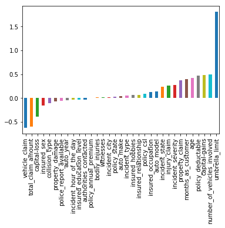

```python
display(fraud_claims_features.skew().sort_values(axis=0))
skewness_data = fraud_claims_features.skew().sort_values(axis=0)
skewness_data.plot.bar()
```

## Features which are highly skewed

The feature which is highly skewed is the umberlla limit. We need to do logarithmic transformation. Logarithimic transformation works only on positive values and if there any negative values, they have to be analysed and see how to make them as positive. If that is not possible, then we need to look for alternate transformations like min max scaler transformation provided by sci-kit learn.

```python
def features_data_check(df,columns_to_check):
    ''' Function to check for any negative values on features where log transformation
        has to be applied'''
    for collist in columns_to_check:
        df1 = df[collist]
        minvalue=df1.min()
        if(minvalue <0):
            print(f"{collist} contains negative values, please check the data")
        else:
            print(f"{collist} does not contain any negative values")
```

```python
## Top skewed features found by data analysis
skewed=["umbrella_limit"]
## Before applying logrithmic transformation
features_data_check(fraud_claims_features,skewed)
```

```
umbrella_limit contains negative values, please check the data
```

### Data Check - Found negative values for Umbrella limit

Umberlla limit has to be positive and analysis of that particular column shows that the value may be incorrectly keyed in as negative. Hence we will take absolute values in the column and do logrithmic transformation.

```python
fraud_claims_features["umbrella_limit"]=fraud_claims_features["umbrella_limit"].abs()
## Again running
print(" Reporting columns after datacheck and fixing the issues")
features_data_check(fraud_claims_features,skewed)
```

```
 Reporting columns after datacheck and fixing the issues
umbrella_limit does not contain any negative values
```

```python
# Apply log transformation
fraud_claims_features[skewed] = fraud_claims_features[skewed].apply(lambda x: np.log(x + 1))
display(fraud_claims_features)
```

|  | months_as_customer | age | policy_state | policy_csl | policy_deductable | policy_annual_premium | umbrella_limit | insured_sex | insured_education_level | insured_occupation | ... | bodily_injuries | witnesses | police_report_available | total_claim_amount | injury_claim | property_claim | vehicle_claim | auto_make | auto_model | auto_year |
| --- | --- | --- | --- | --- | --- | --- | --- | --- | --- | --- | --- | --- | --- | --- | --- | --- | --- | --- | --- | --- | --- |
| 0 | 5 | 3 | 0 | 0 | 1000 | 1406.91 | 0.000000 | 0 | 0 | 0 | ... | 1 | 2 | 0 | 71610 | 6510 | 13020 | 52080 | 0 | 0 | 2004 |
| 1 | 3 | 3 | 1 | 0 | 2000 | 1197.22 | 15.424949 | 0 | 0 | 1 | ... | 0 | 0 | 1 | 5070 | 780 | 780 | 3510 | 1 | 1 | 2007 |
| 2 | 2 | 1 | 0 | 1 | 2000 | 1413.14 | 15.424949 | 1 | 1 | 2 | ... | 2 | 3 | 2 | 34650 | 7700 | 3850 | 23100 | 2 | 2 | 2007 |
| 3 | 4 | 3 | 2 | 0 | 2000 | 1415.74 | 15.607270 | 1 | 1 | 3 | ... | 1 | 2 | 2 | 63400 | 6340 | 6340 | 50720 | 3 | 3 | 2014 |
| 4 | 3 | 3 | 2 | 2 | 1000 | 1583.91 | 15.607270 | 0 | 2 | 2 | ... | 0 | 1 | 2 | 6500 | 1300 | 650 | 4550 | 4 | 4 | 2009 |
| 5 | 4 | 2 | 0 | 0 | 1000 | 1351.10 | 0.000000 | 1 | 1 | 4 | ... | 0 | 2 | 2 | 64100 | 6410 | 6410 | 51280 | 0 | 5 | 2003 |
| 6 | 2 | 2 | 1 | 0 | 1000 | 1333.35 | 0.000000 | 0 | 1 | 5 | ... | 0 | 0 | 1 | 78650 | 21450 | 7150 | 50050 | 5 | 6 | 2012 |
| 7 | 2 | 2 | 2 | 1 | 1000 | 1137.03 | 0.000000 | 0 | 2 | 4 | ... | 2 | 2 | 0 | 51590 | 9380 | 9380 | 32830 | 6 | 7 | 2015 |
| 8 | 0 | 2 | 2 | 1 | 500 | 1442.99 | 0.000000 | 1 | 1 | 6 | ... | 1 | 1 | 0 | 27700 | 2770 | 2770 | 22160 | 7 | 8 | 2012 |
| 9 | 3 | 3 | 2 | 1 | 500 | 1315.68 | 0.000000 | 0 | 1 | 7 | ... | 2 | 1 | 1 | 42300 | 4700 | 4700 | 32900 | 0 | 0 | 1996 |
| 10 | 3 | 3 | 0 | 1 | 500 | 1253.12 | 15.201805 | 1 | 3 | 8 | ... | 2 | 2 | 1 | 87010 | 7910 | 15820 | 63280 | 8 | 9 | 2002 |
| 11 | 7 | 5 | 0 | 1 | 2000 | 1137.16 | 0.000000 | 1 | 4 | 8 | ... | 1 | 2 | 0 | 114920 | 17680 | 17680 | 79560 | 6 | 10 | 2006 |
| 12 | 0 | 1 | 0 | 2 | 500 | 1215.36 | 14.914123 | 0 | 0 | 9 | ... | 1 | 0 | 2 | 56520 | 4710 | 9420 | 42390 | 0 | 5 | 2000 |
| 13 | 2 | 2 | 0 | 1 | 1000 | 936.61 | 0.000000 | 1 | 0 | 3 | ... | 1 | 1 | 2 | 7280 | 1120 | 1120 | 5040 | 7 | 11 | 2010 |
| 14 | 2 | 2 | 0 | 0 | 2000 | 1301.13 | 0.000000 | 1 | 5 | 1 | ... | 0 | 2 | 0 | 46200 | 4200 | 8400 | 33600 | 2 | 12 | 2003 |
| 15 | 7 | 4 | 1 | 1 | 2000 | 1131.40 | 0.000000 | 1 | 0 | 10 | ... | 0 | 0 | 2 | 63120 | 10520 | 10520 | 42080 | 4 | 13 | 1999 |
| 16 | 1 | 1 | 0 | 2 | 1000 | 1199.44 | 15.424949 | 0 | 5 | 1 | ... | 1 | 2 | 0 | 52110 | 5790 | 5790 | 40530 | 5 | 14 | 2012 |
| 17 | 2 | 2 | 1 | 2 | 500 | 708.64 | 15.607270 | 0 | 4 | 1 | ... | 0 | 2 | 0 | 77880 | 14160 | 7080 | 56640 | 9 | 15 | 2015 |
| 18 | 2 | 2 | 0 | 2 | 500 | 1374.22 | 0.000000 | 1 | 0 | 0 | ... | 1 | 0 | 2 | 72930 | 6630 | 13260 | 53040 | 4 | 16 | 2015 |
| 19 | 3 | 2 | 1 | 2 | 2000 | 1475.73 | 0.000000 | 1 | 4 | 11 | ... | 2 | 0 | 2 | 60400 | 6040 | 6040 | 48320 | 5 | 6 | 2014 |
| 20 | 7 | 5 | 1 | 0 | 1000 | 1187.96 | 15.201805 | 0 | 6 | 6 | ... | 1 | 0 | 1 | 47160 | 0 | 5240 | 41920 | 9 | 17 | 2011 |
| 21 | 3 | 3 | 2 | 2 | 2000 | 875.15 | 0.000000 | 1 | 2 | 1 | ... | 1 | 2 | 1 | 37840 | 0 | 4730 | 33110 | 4 | 4 | 1996 |
| 22 | 6 | 4 | 2 | 1 | 2000 | 972.18 | 0.000000 | 0 | 4 | 5 | ... | 0 | 0 | 0 | 71520 | 17880 | 5960 | 47680 | 9 | 18 | 2000 |
| 23 | 6 | 4 | 1 | 1 | 2000 | 1268.79 | 0.000000 | 0 | 0 | 7 | ... | 2 | 2 | 1 | 98160 | 8180 | 16360 | 73620 | 2 | 2 | 2011 |
| 24 | 3 | 2 | 1 | 1 | 1000 | 883.31 | 0.000000 | 0 | 5 | 0 | ... | 1 | 3 | 2 | 77880 | 7080 | 14160 | 56640 | 8 | 19 | 2005 |
| 25 | 0 | 2 | 0 | 1 | 2000 | 1266.92 | 0.000000 | 0 | 3 | 2 | ... | 1 | 3 | 0 | 71500 | 16500 | 11000 | 44000 | 8 | 19 | 2006 |
| 26 | 4 | 3 | 1 | 1 | 2000 | 1322.10 | 0.000000 | 0 | 4 | 5 | ... | 1 | 3 | 0 | 9020 | 1640 | 820 | 6560 | 7 | 8 | 2005 |
| 27 | 3 | 2 | 1 | 1 | 500 | 848.07 | 14.914123 | 0 | 6 | 8 | ... | 2 | 1 | 1 | 5720 | 1040 | 520 | 4160 | 9 | 18 | 2003 |
| 28 | 3 | 2 | 0 | 1 | 2000 | 1291.70 | 0.000000 | 1 | 6 | 2 | ... | 1 | 0 | 0 | 69840 | 7760 | 15520 | 46560 | 2 | 12 | 2009 |
| 29 | 4 | 3 | 2 | 2 | 2000 | 1104.50 | 0.000000 | 1 | 1 | 1 | ... | 2 | 2 | 2 | 91650 | 14100 | 14100 | 63450 | 4 | 16 | 2011 |
| ... | ... | ... | ... | ... | ... | ... | ... | ... | ... | ... | ... | ... | ... | ... | ... | ... | ... | ... | ... | ... | ... |
| 970 | 3 | 2 | 0 | 0 | 500 | 871.46 | 0.000000 | 0 | 0 | 4 | ... | 2 | 0 | 0 | 74140 | 13480 | 6740 | 53920 | 8 | 19 | 2007 |
| 971 | 1 | 1 | 0 | 2 | 500 | 1863.04 | 0.000000 | 1 | 2 | 7 | ... | 2 | 1 | 1 | 67800 | 13560 | 6780 | 47460 | 1 | 22 | 1995 |
| 972 | 3 | 3 | 0 | 0 | 2000 | 1181.64 | 0.000000 | 0 | 5 | 6 | ... | 1 | 1 | 0 | 55400 | 5540 | 11080 | 38780 | 11 | 38 | 2002 |
| 973 | 3 | 2 | 2 | 2 | 1000 | 1060.74 | 0.000000 | 0 | 1 | 4 | ... | 2 | 3 | 1 | 49100 | 9820 | 4910 | 34370 | 9 | 17 | 1996 |
| 974 | 3 | 3 | 1 | 1 | 500 | 951.56 | 0.000000 | 1 | 6 | 10 | ... | 2 | 1 | 1 | 98280 | 15120 | 7560 | 75600 | 3 | 3 | 2007 |
| 975 | 3 | 2 | 1 | 1 | 500 | 1533.71 | 16.012735 | 1 | 6 | 9 | ... | 0 | 2 | 1 | 66550 | 6050 | 12100 | 48400 | 8 | 19 | 2008 |
| 976 | 2 | 2 | 0 | 2 | 1000 | 1200.09 | 0.000000 | 1 | 2 | 0 | ... | 2 | 2 | 1 | 70400 | 14080 | 7040 | 49280 | 4 | 4 | 2002 |
| 977 | 4 | 3 | 1 | 1 | 500 | 1093.83 | 15.201805 | 0 | 2 | 12 | ... | 1 | 1 | 2 | 53280 | 4440 | 8880 | 39960 | 9 | 17 | 2015 |
| 978 | 1 | 2 | 1 | 0 | 1000 | 988.93 | 0.000000 | 1 | 4 | 0 | ... | 2 | 3 | 0 | 84590 | 15380 | 15380 | 53830 | 2 | 12 | 1999 |
| 979 | 3 | 2 | 1 | 2 | 1000 | 1331.94 | 0.000000 | 1 | 3 | 13 | ... | 0 | 2 | 0 | 54560 | 9920 | 9920 | 34720 | 0 | 5 | 2004 |
| 980 | 4 | 2 | 2 | 2 | 1000 | 1361.45 | 0.000000 | 0 | 1 | 11 | ... | 0 | 2 | 0 | 82170 | 7470 | 7470 | 67230 | 9 | 18 | 1999 |
| 981 | 0 | 3 | 0 | 0 | 2000 | 1188.51 | 0.000000 | 0 | 5 | 11 | ... | 1 | 2 | 2 | 61100 | 6110 | 12220 | 42770 | 2 | 12 | 2008 |
| 982 | 3 | 3 | 1 | 2 | 2000 | 1101.83 | 0.000000 | 0 | 4 | 8 | ... | 0 | 3 | 0 | 51900 | 5190 | 10380 | 36330 | 10 | 24 | 2011 |
| 983 | 0 | 2 | 2 | 0 | 1000 | 840.95 | 0.000000 | 1 | 6 | 12 | ... | 2 | 1 | 1 | 3440 | 430 | 430 | 2580 | 9 | 15 | 2002 |
| 984 | 2 | 2 | 1 | 0 | 1000 | 1503.21 | 0.000000 | 0 | 0 | 6 | ... | 2 | 1 | 2 | 51390 | 5710 | 11420 | 34260 | 7 | 20 | 2013 |
| 985 | 0 | 2 | 0 | 1 | 1000 | 1722.50 | 0.000000 | 0 | 4 | 6 | ... | 0 | 2 | 1 | 76900 | 7690 | 7690 | 61520 | 11 | 23 | 1995 |
| 986 | 3 | 3 | 1 | 1 | 500 | 944.03 | 0.000000 | 0 | 5 | 11 | ... | 2 | 3 | 1 | 77000 | 15400 | 7700 | 53900 | 7 | 11 | 2015 |
| 987 | 3 | 2 | 2 | 2 | 2000 | 1453.61 | 15.201805 | 0 | 6 | 0 | ... | 0 | 3 | 1 | 60320 | 9280 | 9280 | 41760 | 3 | 3 | 2012 |
| 988 | 4 | 3 | 1 | 1 | 500 | 1672.88 | 0.000000 | 1 | 4 | 3 | ... | 1 | 1 | 2 | 60700 | 12140 | 6070 | 42490 | 12 | 26 | 1997 |
| 989 | 0 | 1 | 1 | 0 | 1000 | 1248.05 | 0.000000 | 1 | 4 | 8 | ... | 1 | 2 | 1 | 53280 | 5920 | 0 | 47360 | 3 | 33 | 2015 |
| 990 | 4 | 3 | 2 | 1 | 500 | 1564.43 | 14.914123 | 1 | 0 | 5 | ... | 2 | 2 | 0 | 34290 | 3810 | 3810 | 26670 | 11 | 38 | 2013 |
| 991 | 4 | 3 | 0 | 1 | 1000 | 1280.88 | 0.000000 | 0 | 0 | 6 | ... | 0 | 1 | 2 | 46980 | 0 | 5220 | 41760 | 4 | 16 | 2002 |
| 992 | 1 | 1 | 1 | 1 | 500 | 722.66 | 0.000000 | 0 | 0 | 8 | ... | 1 | 2 | 0 | 36700 | 3670 | 7340 | 25690 | 5 | 6 | 2010 |
| 993 | 2 | 1 | 0 | 0 | 1000 | 1235.14 | 0.000000 | 0 | 0 | 8 | ... | 0 | 1 | 1 | 60200 | 6020 | 6020 | 48160 | 13 | 27 | 2012 |
| 994 | 2 | 1 | 1 | 2 | 1000 | 1347.04 | 0.000000 | 0 | 4 | 2 | ... | 1 | 2 | 0 | 6480 | 540 | 1080 | 4860 | 12 | 26 | 1996 |
| 995 | 0 | 2 | 0 | 2 | 1000 | 1310.80 | 0.000000 | 1 | 3 | 0 | ... | 0 | 1 | 1 | 87200 | 17440 | 8720 | 61040 | 12 | 31 | 2006 |
| 996 | 4 | 3 | 2 | 1 | 1000 | 1436.79 | 0.000000 | 1 | 1 | 5 | ... | 2 | 3 | 1 | 108480 | 18080 | 18080 | 72320 | 13 | 27 | 2015 |
| 997 | 2 | 2 | 0 | 0 | 500 | 1383.49 | 14.914123 | 1 | 3 | 3 | ... | 2 | 3 | 0 | 67500 | 7500 | 7500 | 52500 | 9 | 17 | 1996 |
| 998 | 7 | 5 | 2 | 2 | 2000 | 1356.92 | 15.424949 | 0 | 2 | 11 | ... | 0 | 1 | 0 | 46980 | 5220 | 5220 | 36540 | 6 | 7 | 1998 |
| 999 | 7 | 4 | 0 | 0 | 1000 | 766.19 | 0.000000 | 1 | 2 | 2 | ... | 0 | 3 | 1 | 5060 | 460 | 920 | 3680 | 1 | 1 | 2007 |

1000 rows × 33 columns

## Data Analysis

### Check for Skewness of Umbrella limit after log transformation.

```python
display(fraud_claims_features.skew().sort_values(axis=0))
fraud_label = fraud_claims_dataframe["fraud_reported"]
```

```
vehicle_claim                 -0.621098
total_claim_amount            -0.594582
capital-loss                  -0.391472
insured_sex                   -0.148630
collision_type                -0.103128
property_damage               -0.064799
police_report_available       -0.052967
auto_year                     -0.048289
incident_hour_of_the_day      -0.035584
insured_education_level       -0.034161
authorities_contacted         -0.027230
policy_annual_premium          0.004402
bodily_injuries                0.014777
witnesses                      0.019636
incident_city                  0.020657
policy_state                   0.026177
auto_make                      0.041796
incident_type                  0.051461
insured_hobbies                0.067937
insured_relationship           0.073332
policy_csl                     0.092720
insured_occupation             0.124125
auto_model                     0.138466
incident_state                 0.239731
injury_claim                   0.264811
incident_severity              0.279016
property_claim                 0.378169
months_as_customer             0.396584
age                            0.417253
policy_deductable              0.477887
capital-gains                  0.478850
number_of_vehicles_involved    0.502664
umbrella_limit                 1.488544
dtype: float64
```

## From the above , skewness of the umbrella limit has reduced below threshold limit of 1.5 .

## Data Analysis - Corelation between various input features and target variable.

Get Peasrson co-relation co-efficient and draw a heatmap so that exploratory data analysis is easier.

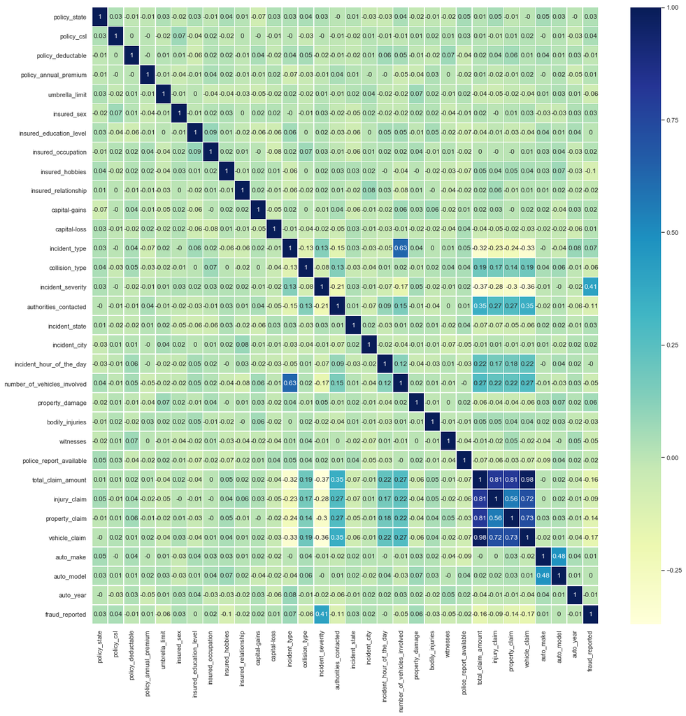

```python
df_corr = fraud_claims_dataframe.corr().round(2)
sns.set(rc={'figure.figsize':(20,20)})
sns.heatmap(df_corr, annot=True,cmap="YlGnBu",linewidths=.5)
```

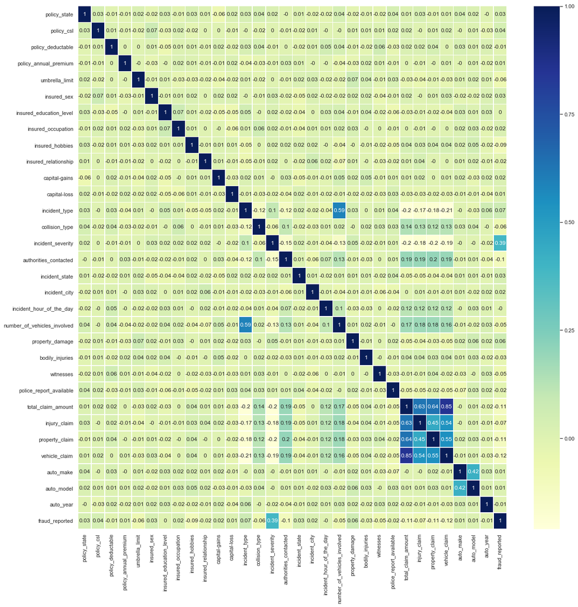

```python
df_corr = fraud_claims_dataframe.corr(method="kendall").round(2)
sns.set(rc={'figure.figsize':(20,20)})
sns.heatmap(df_corr, annot=True,cmap="YlGnBu",linewidths=.5)
```

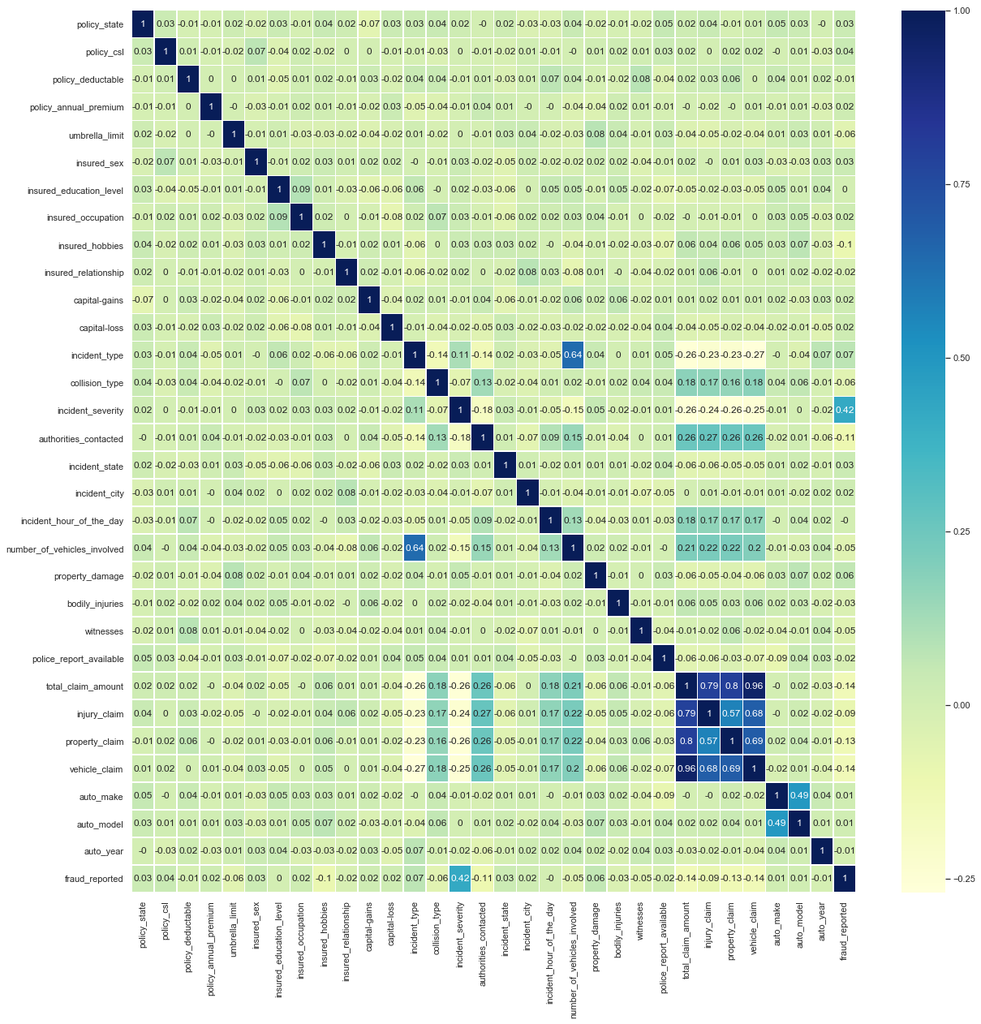

```python
df_corr = fraud_claims_dataframe.corr(method="spearman").round(2)
sns.set(rc={'figure.figsize':(20,20)})
sns.heatmap(df_corr, annot=True,cmap="YlGnBu",linewidths=.5)
## Just for resetting the canvas back
sns.set(rc={'figure.figsize':(12,12)})
```

## Interpretation of heat map

1. Incident severity seems to have some amount of good co-relation with respect to target variable (Fraud or genuine).
2. Total claim amount has co-relation with injuiry claim, property claim and vehicle claim which is expected.
3. Other features are weekly co-related with each other and also target variable (Fraud or geniune) ** Pearson co-relation can be used to understand linear relationships whereas kendall and spearman can be used to under non linear relationships.

## Model selection - Benchmark and Models choosen to study.

The solution would be for the model to predict will be predictions of whether a auto insurance claim is fraud or not. This is a classification problem and most common solution to these problems are to use SVM,Decision tree,Random Forest, Gradient Boosting even though all of them can be used for regression problems also. Fraud detection patterns are complex and the current dataset contains only around 1000 records. SVM is generally used when the dataset size is very less and features are high. This is for the precise reason SVM is chosen as one of the model. Disadvantage of SVM is that they tend to take lot of time during training. Decision trees are easy to visualise, takes less time to train. The disadvantage is that they tend to overfit . The overfit could be reduced by simply averaging out the predictors like in Random Forest or by repeatedly train trees on the residuals of the previous predictors like GBM. This is for the reason Decision Tree, Random Forest and GBM are chosen as other model solutions along with SVM.

```python
def plot_confusion_matrix(cm, classes,
                          normalize=False,
                          title='Confusion matrix',
                          cmap=plt.cm.Blues):
    # This basically calculates the percentage of correct vs wrong.
    if normalize:
        cm = cm.astype('float') / cm.sum(axis=1)[:, np.newaxis]
        print("Normalized confusion matrix")
    else:
        print('Confusion matrix, without normalization')

    print(cm)

    plt.figure(figsize=(5,5))
    plt.imshow(cm, interpolation='nearest', cmap=cmap)
    plt.title(title)
    plt.colorbar()
    tick_marks = np.arange(len(classes))
    plt.xticks(tick_marks, classes, rotation=45)
    plt.yticks(tick_marks, classes)

    fmt = '.2f' if normalize else 'd'
    thresh = cm.max() / 2.
    for i, j in itertools.product(range(cm.shape[0]), range(cm.shape[1])):
        plt.text(j, i, format(cm[i, j], fmt),
                 horizontalalignment="center",
                 color="white" if cm[i, j] > thresh else "black")

    plt.tight_layout()
    plt.ylabel('True label')
    plt.xlabel('Predicted label')
    plt.show()
```

```python
def f_importances(coef, names):
    imp = coef
    df = pd.DataFrame(data=imp, columns=names).transpose()
    df = df.sort_values(df.columns[0])
    display(df)
    df.plot(kind="barh",figsize=(20,20))
```

```python
def importantFeatures(model_fit,index):
    # Compute confusion matrix
    # We have three models, so lets put in a loop and iterate them

    if(index==0):
        feature_names=list(X_train.columns)
        f_importances(model_fit.coef_, feature_names)
    if (index==1):
        print(f"Features relevant are {model_fit.feature_importances_}")
        feature_importances = pd.DataFrame(model_fit.feature_importances_,
                                   index = X_train.columns,
                                    columns=['importance']).sort_values('importance',ascending=False)
        print(f"feature_importances in decision tree is {feature_importances}")
        feature_importances.plot.bar(figsize=(20,20))
    if (index==2):
        print(f"Features relevant are {model_fit.feature_importances_}")
        feature_importances = pd.DataFrame(model_fit.feature_importances_,
                                   index = X_train.columns,
                                    columns=['importance']).sort_values('importance',ascending=False)
        feature_importances.plot.bar(figsize=(20,20))
        print(f"feature_importances in Random Forest  is {feature_importances}")
    if (index==3):
        print(f"Features relevant are {model_fit.feature_importances_}")
        feature_importances = pd.DataFrame(model_fit.feature_importances_,
                                   index = X_train.columns,
                                    columns=['importance']).sort_values('importance',ascending=False)
        print(f"feature_importances in Gradient boosting is {feature_importances}")
        feature_importances.plot.bar(figsize=(20,20))
```

```python
from sklearn.metrics import accuracy_score
from sklearn.metrics import fbeta_score
import datetime

def train_predict(learner, X_train, y_train, X_test, y_test,index):
    '''
    inputs:
       - learner: the learning algorithm to be trained and predicted on
       - sample_size: the size of samples (number) to be drawn from training set
       - X_train: features training set
       - y_train: income training set
       - X_test: features testing set
       - y_test: income testing set
    '''

    results = {}
    sample_size ="Running on Entire Dataset"
    startTime = datetime.datetime.now()
    print("**********************************************************")
    print(f"{learner.__class__.__name__}")
    print("***********************************************************\n")
    print("----------------------------------------------------")
    print(" ")
    print(f"{learner.__class__.__name__} : Training Start Time is {startTime}")
    learner = learner.fit(X_train,y_train)
    endTime = datetime.datetime.now()
    print(f"{learner.__class__.__name__} : Training End Time is {endTime}")
    print(f"Total time taken to learn on  training data for sample size: {sample_size} is : {endTime-startTime} Seconds")
    print(" ")
    print("---------------------------------------------------")

    # Calculate the training time
    results['train_time'] = endTime-startTime
    startTime = datetime.datetime.now()
    print("---------------------------------------------------")
    print(" ")
    print(f"{learner.__class__.__name__} : Prediction Start Time on test dataset is {startTime}")
    predictions_test = learner.predict(X_test)
    endTime = datetime.datetime.now()
    print(f"{learner.__class__.__name__} : Prediction End Time on test dataset is {endTime}")
    print(f"Total time taken for prediction on testing data  is : {endTime-startTime} Seconds")
    print(" ")
    print("----------------------------------------------------")

    startTime = datetime.datetime.now()
    print(f"{learner.__class__.__name__} : Prediction Start Time on training dataset is {startTime}")
    predictions_train = learner.predict(X_train)

    endTime = datetime.datetime.now()
    print(f"{learner.__class__.__name__} : Prediction End Time on training dataset is is {endTime}")
    print(f"Total time taken to predict on training data for sample size: {sample_size} is : {endTime-startTime} Seconds")
    print("-----------------------------------------------------")
    print(" ")

    # Calculate the total prediction time
    results['pred_time'] = endTime-startTime

    #Compute accuracy on the training samples
    results['acc_train'] = accuracy_score(y_train,predictions_train)

    #Compute accuracy on test set using accuracy_score()
    results['acc_test'] = accuracy_score(y_test,predictions_test)

    #Compute F-score on the training samples using fbeta_score()
    results['f_train'] = fbeta_score(y_train,predictions_train,0.5) ## our beta classifier is 0.5

    #Compute F-score on the test set which is y_test
    results['f_test'] =  fbeta_score(y_test,predictions_test,0.5)

    print("{} trained on {} samples.".format(learner.__class__.__name__, sample_size))
    print("--------------------------------------------------------")
    print(" ")
    print(" ")
    print(" ")
    # Return the results
    print("**** Important Features of Different Classifiers ****")
    importantFeatures(learner,index)
    print("*** Confusion Matrix ********************************")
    class_names =["Genuine","Fraud"]
    cnf_matrix = confusion_matrix(y_test,predictions_test)
    np.set_printoptions(precision=2)
    plt.figure(i)
    model_name=learner.__class__.__name__
    plot_confusion_matrix(cnf_matrix, classes=class_names, normalize=False,
                          title='Confusion matrix' + ": "+ model_name)
    plt.show()
    plot_confusion_matrix(cnf_matrix, classes=class_names, normalize=True,
                          title='Confusion matrix' + ": "+ model_name)
    plt.show()
    return results
```

```
Training set has 800 samples.
Testing set has 200 samples.
Training set has 800 samples.
Testing set has 200 samples.
SVC

----------------------------------------------------

SVC : Training Start Time is 2018-11-25 21:56:36.501265
SVC : Training End Time is 2018-11-25 23:31:55.919129
Total time taken to learn on  training data for sample size: Running on Entire Dataset is : 1:35:19.417864 Seconds

---------------------------------------------------
---------------------------------------------------

SVC : Prediction Start Time on test dataset is 2018-11-25 23:31:55.920282
SVC : Prediction End Time on test dataset is 2018-11-25 23:31:55.938165
Total time taken for prediction on testing data  is : 0:00:00.017883 Seconds

----------------------------------------------------
SVC : Prediction Start Time on training dataset is 2018-11-25 23:31:55.938964
SVC : Prediction End Time on training dataset is is 2018-11-25 23:31:55.999073
Total time taken to predict on training data for sample size: Running on Entire Dataset is : 0:00:00.060109 Seconds
-----------------------------------------------------

SVC trained on Running on Entire Dataset samples.
--------------------------------------------------------



**** Important Features of Different Classifiers ****
```

|  | 0 |
| --- | --- |
| insured_hobbies | -63.494768 |
| insured_occupation | -58.821008 |
| insured_relationship | -42.311544 |
| umbrella_limit | -36.328634 |
| incident_city | -32.341966 |
| bodily_injuries | -20.416879 |
| auto_model | -16.157267 |
| age | -15.904261 |
| witnesses | -12.055027 |
| police_report_available | -8.081599 |
| months_as_customer | -6.698960 |
| incident_hour_of_the_day | -6.693169 |
| authorities_contacted | -4.983850 |
| property_claim | -0.065995 |
| collision_type | -0.062102 |
| vehicle_claim | -0.024607 |
| capital-loss | -0.017570 |
| capital-gains | 0.015319 |
| total_claim_amount | 0.022579 |
| injury_claim | 0.113181 |
| policy_deductable | 0.208551 |
| policy_annual_premium | 0.227806 |
| auto_year | 9.287174 |
| number_of_vehicles_involved | 10.082797 |
| insured_education_level | 13.135516 |
| insured_sex | 16.518069 |
| incident_type | 18.027521 |
| policy_state | 19.661114 |
| property_damage | 20.550415 |
| policy_csl | 20.850695 |
| incident_state | 30.867239 |
| auto_make | 42.078689 |
| incident_severity | 136.231522 |

```
*** Confusion Matrix ********************************
Confusion matrix, without normalization
[[  1  56]
 [  1 142]]
```

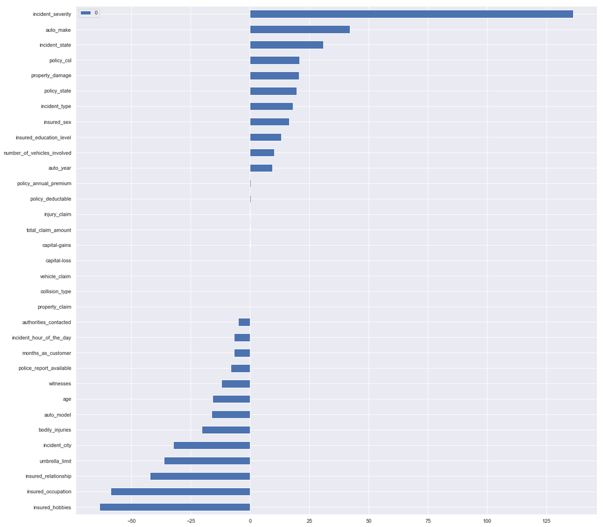

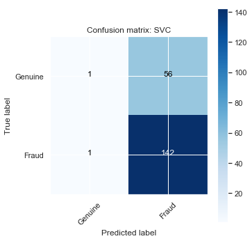

```
Normalized confusion matrix
[[0.02 0.98]
 [0.01 0.99]]
```

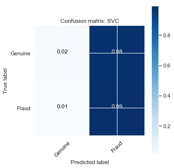

```
DecisionTreeClassifier

----------------------------------------------------

DecisionTreeClassifier : Training Start Time is 2018-11-25 23:32:01.016816
DecisionTreeClassifier : Training End Time is 2018-11-25 23:32:01.117245
Total time taken to learn on  training data for sample size: Running on Entire Dataset is : 0:00:00.100429 Seconds

---------------------------------------------------
---------------------------------------------------

DecisionTreeClassifier : Prediction Start Time on test dataset is 2018-11-25 23:32:01.123858
DecisionTreeClassifier : Prediction End Time on test dataset is 2018-11-25 23:32:01.137073
Total time taken for prediction on testing data  is : 0:00:00.013215 Seconds

----------------------------------------------------
DecisionTreeClassifier : Prediction Start Time on training dataset is 2018-11-25 23:32:01.137692
DecisionTreeClassifier : Prediction End Time on training dataset is is 2018-11-25 23:32:01.156784
Total time taken to predict on training data for sample size: Running on Entire Dataset is : 0:00:00.019092 Seconds
-----------------------------------------------------

DecisionTreeClassifier trained on Running on Entire Dataset samples.
--------------------------------------------------------



**** Important Features of Different Classifiers ****
Features relevant are [0.01 0.   0.02 0.02 0.   0.01 0.01 0.   0.01 0.02 0.22 0.01 0.01 0.02
 0.01 0.   0.26 0.01 0.01 0.01 0.02 0.   0.01 0.01 0.02 0.03 0.02 0.04
 0.07 0.01 0.02 0.03 0.03]
feature_importances in decision tree is                              importance
incident_severity              0.260099
insured_hobbies                0.223709
property_claim                 0.068595
injury_claim                   0.044356
auto_model                     0.034669
auto_year                      0.031686
police_report_available        0.030334
insured_occupation             0.023735
auto_make                      0.023263
```

[output cut: 13 more lines]

```
insured_relationship           0.010354
bodily_injuries                0.010217
authorities_contacted          0.010194
umbrella_limit                 0.009151
policy_annual_premium          0.006212
incident_type                  0.005177
insured_sex                    0.003451
age                            0.001121
number_of_vehicles_involved    0.000000
policy_deductable              0.000000
collision_type                 0.000000
*** Confusion Matrix ********************************
Confusion matrix, without normalization
[[ 32  25]
 [ 15 128]]
```

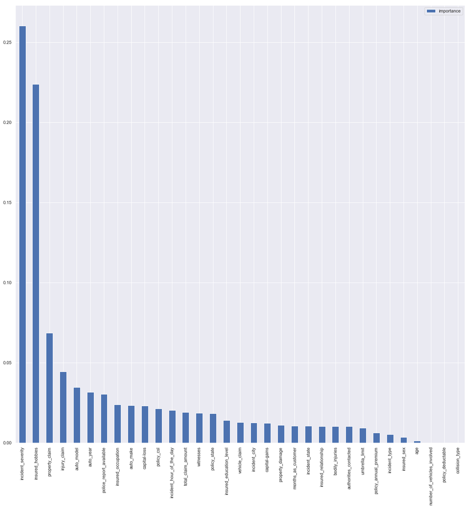

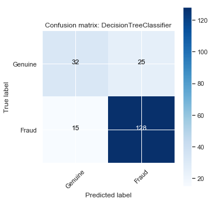

```
Normalized confusion matrix
[[0.56 0.44]
 [0.1  0.9 ]]
```

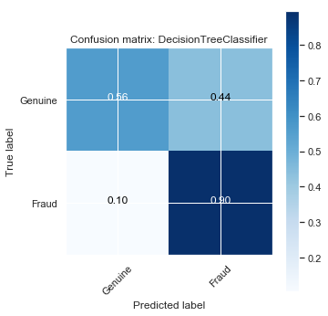

```
RandomForestClassifier

----------------------------------------------------

RandomForestClassifier : Training Start Time is 2018-11-25 23:32:05.595776
RandomForestClassifier : Training End Time is 2018-11-25 23:32:05.758344
Total time taken to learn on  training data for sample size: Running on Entire Dataset is : 0:00:00.162568 Seconds

---------------------------------------------------
---------------------------------------------------

RandomForestClassifier : Prediction Start Time on test dataset is 2018-11-25 23:32:05.759109
RandomForestClassifier : Prediction End Time on test dataset is 2018-11-25 23:32:05.781268
Total time taken for prediction on testing data  is : 0:00:00.022159 Seconds

----------------------------------------------------
RandomForestClassifier : Prediction Start Time on training dataset is 2018-11-25 23:32:05.782803
RandomForestClassifier : Prediction End Time on training dataset is is 2018-11-25 23:32:05.818798
Total time taken to predict on training data for sample size: Running on Entire Dataset is : 0:00:00.035995 Seconds
-----------------------------------------------------

RandomForestClassifier trained on Running on Entire Dataset samples.
--------------------------------------------------------



**** Important Features of Different Classifiers ****
Features relevant are [0.03 0.02 0.01 0.02 0.01 0.05 0.02 0.01 0.02 0.03 0.07 0.02 0.02 0.03
 0.01 0.01 0.18 0.01 0.04 0.03 0.05 0.01 0.01 0.01 0.02 0.01 0.04 0.06
 0.05 0.04 0.03 0.03 0.03]
feature_importances in Random Forest  is                              importance
incident_severity              0.184578
insured_hobbies                0.067013
injury_claim                   0.056918
incident_hour_of_the_day       0.049443
policy_annual_premium          0.046323
property_claim                 0.045836
total_claim_amount             0.040019
vehicle_claim                  0.039407
incident_state                 0.038353
```

[output cut: 13 more lines]

```
policy_csl                     0.015774
property_damage                0.014514
policy_state                   0.013600
authorities_contacted          0.013284
bodily_injuries                0.013170
collision_type                 0.013031
police_report_available        0.009408
policy_deductable              0.009174
number_of_vehicles_involved    0.008627
incident_type                  0.005120
insured_sex                    0.005032
*** Confusion Matrix ********************************
Confusion matrix, without normalization
[[ 24  33]
 [ 13 130]]
```

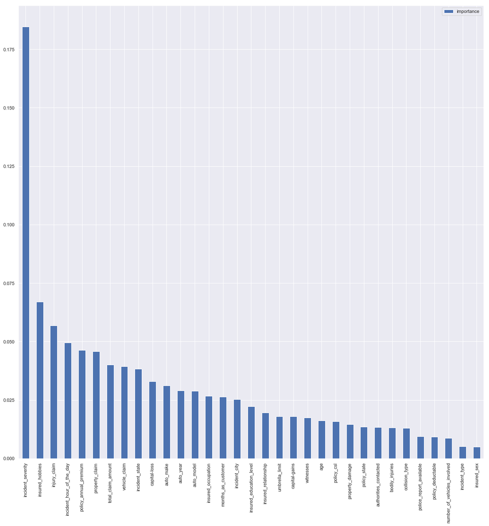

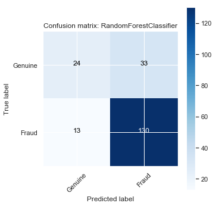

```
Normalized confusion matrix
[[0.42 0.58]
 [0.09 0.91]]
```

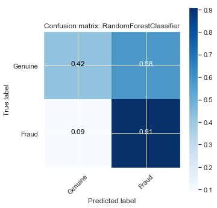

```
GradientBoostingClassifier

----------------------------------------------------

GradientBoostingClassifier : Training Start Time is 2018-11-25 23:32:11.921625
GradientBoostingClassifier : Training End Time is 2018-11-25 23:32:13.154140
Total time taken to learn on  training data for sample size: Running on Entire Dataset is : 0:00:01.232515 Seconds

---------------------------------------------------
---------------------------------------------------

GradientBoostingClassifier : Prediction Start Time on test dataset is 2018-11-25 23:32:13.154967
GradientBoostingClassifier : Prediction End Time on test dataset is 2018-11-25 23:32:13.164036
Total time taken for prediction on testing data  is : 0:00:00.009069 Seconds

----------------------------------------------------
GradientBoostingClassifier : Prediction Start Time on training dataset is 2018-11-25 23:32:13.167135
GradientBoostingClassifier : Prediction End Time on training dataset is is 2018-11-25 23:32:13.197896
Total time taken to predict on training data for sample size: Running on Entire Dataset is : 0:00:00.030761 Seconds
-----------------------------------------------------

GradientBoostingClassifier trained on Running on Entire Dataset samples.
--------------------------------------------------------



**** Important Features of Different Classifiers ****
Features relevant are [0.03 0.02 0.   0.02 0.   0.06 0.02 0.   0.01 0.03 0.15 0.01 0.04 0.06
 0.01 0.01 0.12 0.01 0.03 0.02 0.04 0.   0.   0.   0.   0.02 0.04 0.05
 0.08 0.04 0.02 0.03 0.02]
feature_importances in Gradient boosting is                              importance
insured_hobbies                0.153634
incident_severity              0.123108
property_claim                 0.079750
capital-loss                   0.061636
policy_annual_premium          0.059738
injury_claim                   0.047525
capital-gains                  0.044389
total_claim_amount             0.040795
vehicle_claim                  0.037077
```

[output cut: 13 more lines]

```
insured_education_level        0.010433
incident_type                  0.010039
collision_type                 0.006827
authorities_contacted          0.006543
bodily_injuries                0.004323
policy_deductable              0.003420
policy_state                   0.003172
number_of_vehicles_involved    0.002970
property_damage                0.002800
witnesses                      0.000351
insured_sex                    0.000000
*** Confusion Matrix ********************************
Confusion matrix, without normalization
[[ 30  27]
 [ 14 129]]
```

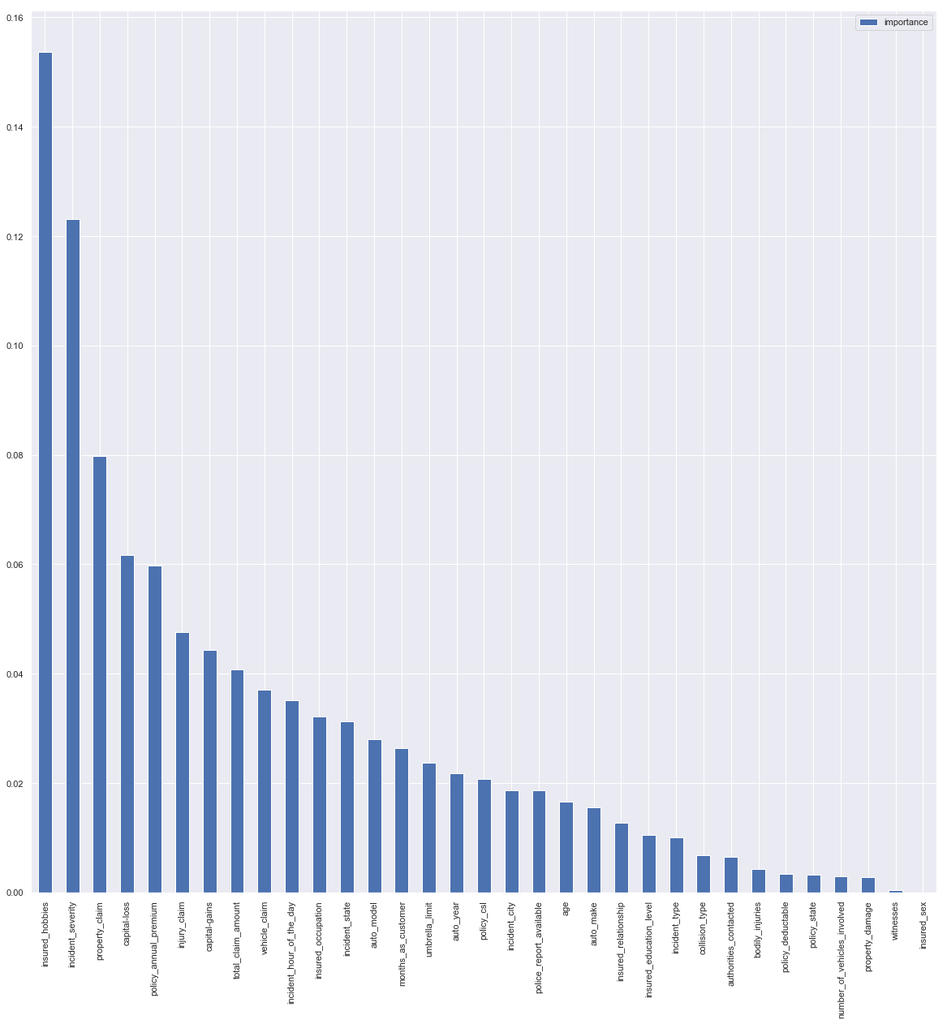

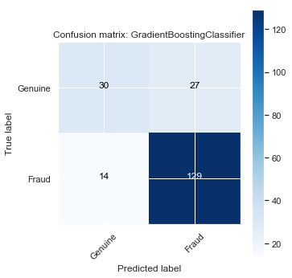

```
Normalized confusion matrix
[[0.53 0.47]
 [0.1  0.9 ]]
```

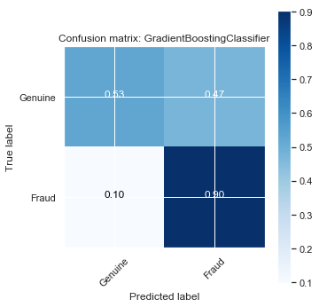

|  | SVC | DecisionTreeClassifier | RandomForestClassifier | GradientBoostingClassifier |
| --- | --- | --- | --- | --- |
| acc_test | 0.715 | 0.8 | 0.77 | 0.795 |
| acc_train | 0.7575 | 1 | 0.9875 | 0.9825 |
| f_test | 0.759358 | 0.847682 | 0.81761 | 0.840939 |
| f_train | 0.800106 | 1 | 0.989889 | 0.98475 |
| pred_time | 0:00:00.060109 | 0:00:00.019092 | 0:00:00.035995 | 0:00:00.030761 |
| train_time | 1:35:19.417864 | 0:00:00.100429 | 0:00:00.162568 | 0:00:01.232515 |

```python
# Split the 'features' and 'income' data into training and testing sets
X_train, X_test, y_train, y_test = train_test_split(fraud_claims_features,
                                                    fraud_label,
                                                    test_size = 0.20,
                                                    random_state = 0)

# Show the results of the split
print("Training set has {} samples.".format(X_train.shape[0]))
print("Testing set has {} samples.".format(X_test.shape[0]))
# Initialize the three models
clf_A = SVC(kernel='linear')
clf_B = DecisionTreeClassifier()
clf_C = RandomForestClassifier()
clf_D = GradientBoostingClassifier()



# Show the results of the split
print("Training set has {} samples.".format(X_train.shape[0]))
print("Testing set has {} samples.".format(X_test.shape[0]))


# Collect results on the learners
results = {}
for i,clf in enumerate([clf_A, clf_B, clf_C,clf_D]):
    clf_name = clf.__class__.__name__
    results[clf_name] = {}
    results[clf_name] = \
        train_predict(clf,  X_train, y_train, X_test, y_test,i)

# Run metrics visualization for the four supervised learning models chosen
print("*****")

display(pd.DataFrame(results))
```

### Model selection and Model Tuning

1. Insure Hobbies
2. Incident Severity
3. Proper Claim
4. Policy Annual Premium.

Lets drop all other features and again train the model and do the prediction to understand whether the accuracy/F-score increases.

```
Training set has 800 samples.
Testing set has 200 samples.
Training set has 800 samples.
Testing set has 200 samples.
GradientBoostingClassifier

----------------------------------------------------

GradientBoostingClassifier : Training Start Time is 2018-11-26 00:00:07.226302
GradientBoostingClassifier : Training End Time is 2018-11-26 00:00:07.369037
Total time taken to learn on  training data for sample size: Running on Entire Dataset is : 0:00:00.142735 Seconds

---------------------------------------------------
---------------------------------------------------

GradientBoostingClassifier : Prediction Start Time on test dataset is 2018-11-26 00:00:07.369355
GradientBoostingClassifier : Prediction End Time on test dataset is 2018-11-26 00:00:07.370487
Total time taken for prediction on testing data  is : 0:00:00.001132 Seconds

----------------------------------------------------
GradientBoostingClassifier : Prediction Start Time on training dataset is 2018-11-26 00:00:07.370722
GradientBoostingClassifier : Prediction End Time on training dataset is is 2018-11-26 00:00:07.374040
Total time taken to predict on training data for sample size: Running on Entire Dataset is : 0:00:00.003318 Seconds
-----------------------------------------------------

GradientBoostingClassifier trained on Running on Entire Dataset samples.
--------------------------------------------------------



**** Important Features of Different Classifiers ****
Features relevant are [0.7 0.3]
feature_importances in Gradient boosting is                    importance
insured_hobbies      0.700366
incident_severity    0.299634
*** Confusion Matrix ********************************
Confusion matrix, without normalization
[[ 40  17]
 [ 13 130]]
```

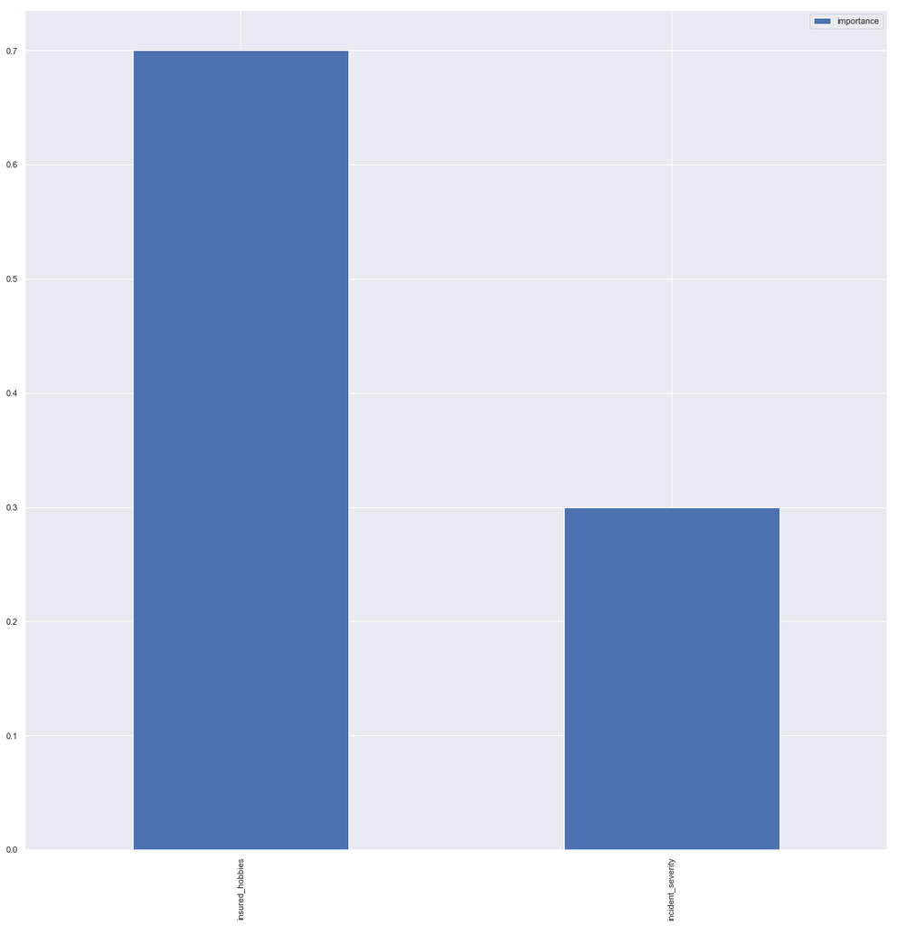

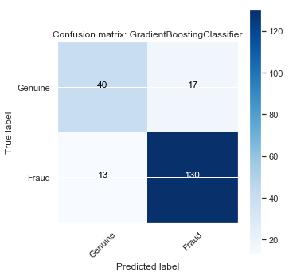

```
Normalized confusion matrix
[[0.7  0.3 ]
 [0.09 0.91]]
```

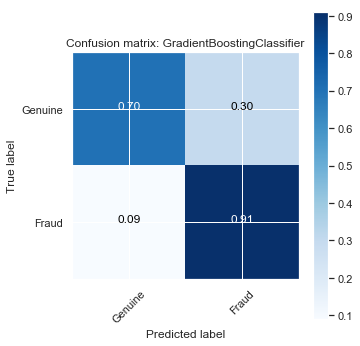

|  | GradientBoostingClassifier |
| --- | --- |
| acc_test | 0.85 |
| acc_train | 0.86875 |
| f_test | 0.889193 |
| f_train | 0.923729 |
| pred_time | 0:00:00.003318 |
| train_time | 0:00:00.142735 |

```python
#list_relevant_features =["insured_hobbies","incident_severity","property_claim","policy_annual_premium","capital-loss"]
list_relevant_features =["insured_hobbies","incident_severity"]

fraud_claim_relevant_features = fraud_claims_features[list_relevant_features]
X_train, X_test, y_train, y_test = train_test_split(fraud_claim_relevant_features,
                                                    fraud_label,
                                                    test_size = 0.2,
                                                    random_state = 0)

# Show the results of the split
print("Training set has {} samples.".format(X_train.shape[0]))
print("Testing set has {} samples.".format(X_test.shape[0]))

clf_D = GradientBoostingClassifier()



# Show the results of the split
print("Training set has {} samples.".format(X_train.shape[0]))
print("Testing set has {} samples.".format(X_test.shape[0]))
# Collect results on the learners
results = {}
clf_name = clf_D.__class__.__name__
results[clf_name] = {}
results[clf_name] = \
        train_predict(clf_D,  X_train, y_train, X_test, y_test,3)

# Run metrics visualization for the three supervised learning models chosen
print("*****")
display(pd.DataFrame(results))
```

## Using grid search and tuning parameters

After dropping the irelevant features, we could see that the accuracy and F-Score has increaaed by around 5%. Lets find whether further parameter tuning using grid search could be used to improve the accuracy and F-Score.

```
Start Time is 2018-11-26 00:00:41.556451
Feature Optimised model
------
Accuracy score on testing data: 0.8500
F-score on testing data: 0.8892

 Feature and Parameter Optimized Model
------
Final accuracy score on the testing data: 0.8400
Final F-score on the testing data: 0.8852
Classifier on non-optimised model
GradientBoostingClassifier(criterion='friedman_mse', init=None,
              learning_rate=0.1, loss='deviance', max_depth=3,
              max_features=None, max_leaf_nodes=None,
              min_impurity_decrease=0.0, min_impurity_split=None,
              min_samples_leaf=1, min_samples_split=2,
              min_weight_fraction_leaf=0.0, n_estimators=100,
              presort='auto', random_state=None, subsample=1.0, verbose=0,
              warm_start=False)


Classifier on optimised model
GradientBoostingClassifier(criterion='friedman_mse', init=None,
              learning_rate=0.1, loss='exponential', max_depth=3,
              max_features=None, max_leaf_nodes=None,
              min_impurity_decrease=0.0, min_impurity_split=None,
              min_samples_leaf=2, min_samples_split=2,
              min_weight_fraction_leaf=0.0, n_estimators=100,
              presort='auto', random_state=None, subsample=1.0, verbose=0,
              warm_start=False)
End Time is 2018-11-26 00:03:57.246829
*** Confusion Matrix ********************************
Confusion matrix, without normalization
[[ 40  17]
 [ 15 128]]
```

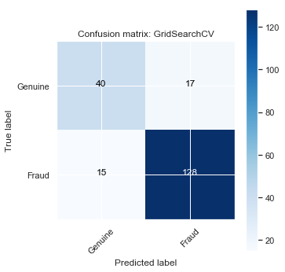

```
Normalized confusion matrix
[[0.7 0.3]
 [0.1 0.9]]
```

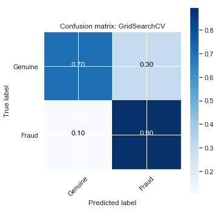

```python
startTime = datetime.datetime.now()
print(f"Start Time is {startTime}")
clf = GradientBoostingClassifier()

#Parameters to be tuned.
parameters =  {"loss":["deviance","exponential"],"max_depth":[2,3,4,5,10],"min_samples_leaf":[1,2,3,4,5,6,7,8,9,10,11,12]}

# Fbeta_score scoring object using make_scorer()
scorer = make_scorer(fbeta_score,beta=0.5)

# Perform grid search on the classifier using 'scorer' as the scoring method using GridSearchCV()
grid_obj = GridSearchCV(clf,parameters,scorer)

#it the grid search object to the training data and find the optimal parameters using fit()
grid_fit = grid_obj.fit(X_train,y_train)

# Get the best estimator
best_clf = grid_fit.best_estimator_

# Make predictions using the  Feature optimized and model
predictions = (clf.fit(X_train, y_train)).predict(X_test)
# Make predictions based on Feature and parameter tuning optimised model
best_predictions = best_clf.predict(X_test)


# Report the before-and-afterscores
print("Feature Optimised model\n------")
print("Accuracy score on testing data: {:.4f}".format(accuracy_score(y_test, predictions)))
print("F-score on testing data: {:.4f}".format(fbeta_score(y_test, predictions, beta = 0.5)))
print("\n Feature and Parameter Optimized Model\n------")
print("Final accuracy score on the testing data: {:.4f}".format(accuracy_score(y_test, best_predictions)))
print("Final F-score on the testing data: {:.4f}".format(fbeta_score(y_test, best_predictions, beta = 0.5)))
## classifier used on unoptimised model
print("Classifier on non-optimised model")
print(clf)
print("\n")
## classifier used on optimised model
print("Classifier on optimised model")
print(best_clf)
endTime = datetime.datetime.now()
print(f"End Time is {endTime}")

print("*** Confusion Matrix ********************************")
class_names =["Genuine","Fraud"]
cnf_matrix = confusion_matrix(y_test,best_predictions)
np.set_printoptions(precision=2)
# Plot normalized confusion matrix
plt.figure(i)
model_name=grid_fit.__class__.__name__
plot_confusion_matrix(cnf_matrix, classes=class_names, normalize=False,
                          title='Confusion matrix' + ": "+ model_name)
plt.show()
plot_confusion_matrix(cnf_matrix, classes=class_names, normalize=True,
                          title='Confusion matrix' + ": "+ model_name)
plt.show()
```

## Conclusion

Choosing relevant features improved prediction in gradient boosting tree. But at the same time further parameter tuning did not yield better results .

## Initial Model - Benchmark used is Gradient boost

[figure not shown]

## Final Model - After tuning - Gradient Boost

1. Accuracy score on testing data: 0.84
2. F-score on testing data: 0.8852

#### Improvement of F-Score in Final Model compared to BenchMarch - 5%